# DS_CA7_810100194_810100084_810100272

Datascience - CA7

Amirmahdi Farzane - 810100194

Mohammad Amanlou - 810100084

Shahzad Momayez - 810100272

```python
!pip install -U accelerate   # first run this, then go runtime - >  restart session
!pip install -U transformers
```

```python
import torch
from transformers import AutoModelForCausalLM, AutoTokenizer, pipeline
```

```python
device = "cuda" if torch.cuda.is_available() else "cpu"
device
```

```
'cuda'
```

```python
from google.colab import drive
drive.mount('/content/drive')
```

```python
import numpy as np
import pandas as pd
import matplotlib.pyplot as plt
import re
import string
import math
```

```python
train_df = pd.read_json("/content/drive/MyDrive/imdb/train_imdb.jsonl", lines=True)
test_df = pd.read_json("/content/drive/MyDrive/imdb/test_imdb.jsonl", lines=True)
unlabeled_df = pd.read_json("/content/drive/MyDrive/imdb/aug_imdb_unlabeled.jsonl", lines=True)
```

```python
train_df.head()
```

|  | text | label | embedding |
| --- | --- | --- | --- |
| 0 | fairly good romantic comedy in which i don't t... | 1 | [-0.0167805497, -0.0395836979, 0.1233159453000... |
| 1 | "dressed to kill", is one of the best thriller... | 1 | [-0.12526972590000002, 0.10147688540000001, 0.... |
| 2 | i'm glad that users (as of this date) who like... | 1 | [0.1312361956, 0.0294876788, 0.2328549027, -0.... |
| 3 | needed an excuse to get out of the house while... | 0 | [0.1387384981, 0.0460377187, 0.3447172046, -0.... |
| 4 | john candy's performance in once upon a crime ... | 1 | [0.1606466323, -0.1768193543, 0.35633808370000... |

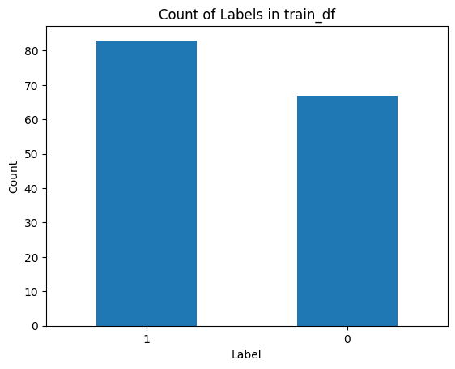

```python
from matplotlib import pyplot as plt
def count_of_label(df):
  label_counts = df['label'].value_counts()
  label_counts.plot(kind='bar')
  plt.xlabel('Label')
  plt.ylabel('Count')
  plt.title('Count of Labels in train_df')
  plt.xticks(rotation=0)  # Keep the x labels horizontal
  plt.show()
count_of_label(train_df)
```

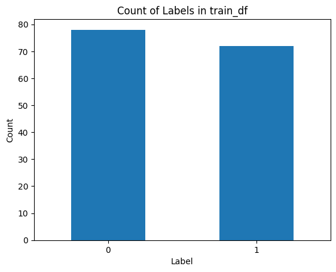

```python
count_of_label(test_df)
```

```python
print(f"shape of train set : {train_df.shape}")
print(f"shape of test set : {test_df.shape}")
print(f"shape of unlabeled set : {unlabeled_df.shape}")
```

```
shape of train set : (150, 3)
shape of test set : (150, 3)
shape of unlabeled set : (1014, 2)
```

### checking null values

```python
train_df.isnull().sum()
```

```
text         0
label        0
embedding    0
dtype: int64
```

```python
test_df.isnull().sum()
```

```
text         0
label        0
embedding    0
dtype: int64
```

```python
unlabeled_df.isnull().sum()
```

```
text         0
embedding    0
dtype: int64
```

```python
for index,text in enumerate(train_df['text'][35:40]):
  print('Review %d:\n'%(index+1),text)
```

```
Review 1:
 burlinson and thornton give an outstanding performance in this movie, along with dennehy. although it is at first thought to be only about love, it really goes down deeper than that. the beauty of nature captures this movie, placing among one of the best i have ever seen. the horse scenes are absol…
Review 2:
 the plot of the story and the performance of the lead actors are very much down-to-earth! the romance between two teen-age boys on the screen was done in good taste. you can easily relate to their emotions if you are one but if you are not one, you can appreciate the kind of love the film is trying…
Review 3:
 this a superb self-contained work that is unconnected with anything before or after. brat pack crooning and club exclusivity are not my biscuits of choice, but in this law-free world they make an alluring ambiance. the film is packed with our guys, distinctive actors who add distinction to this wor…
Review 4:
 i saw this movie with my dad. i must have been pretty young, around 15. it was on star movies one afternoon.the movie started a bit vaguely, but you could tell those robbers were gathering up for a score. it really caught pace after the first half hour.<br /><br />all the actors are great, especial…
Review 5:
 so you think a talking parrot is not your cup of tea huh? well, think again. paulie is a wonderful film filled with touching moments.the characters are all lovable especially paulie as he enters the lives of many people on his journey.it is journey worth experiencing. don't miss it! it is available…
```

### convert contractions

```python
# Dictionary of English Contractions
contractions_dict = { "ain't": "are not","'s":" is","aren't": "are not",
                     "can't": "cannot","can't've": "cannot have",
                     "'cause": "because","could've": "could have","couldn't": "could not",
                     "couldn't've": "could not have", "didn't": "did not","doesn't": "does not",
                     "don't": "do not","hadn't": "had not","hadn't've": "had not have",
                     "hasn't": "has not","haven't": "have not","he'd": "he would",
                     "he'd've": "he would have","he'll": "he will", "he'll've": "he will have",
                     "how'd": "how did","how'd'y": "how do you","how'll": "how will",
                     "I'd": "I would", "I'd've": "I would have","I'll": "I will",
                     "I'll've": "I will have","I'm": "I am","I've": "I have", "isn't": "is not",
                     "it'd": "it would","it'd've": "it would have","it'll": "it will",
                     "it'll've": "it will have", "let's": "let us","ma'am": "madam",
                     "mayn't": "may not","might've": "might have","mightn't": "might not",
                     "mightn't've": "might not have","must've": "must have","mustn't": "must not",
                     "mustn't've": "must not have", "needn't": "need not",
                     "needn't've": "need not have","o'clock": "of the clock","oughtn't": "ought not",
                     "oughtn't've": "ought not have","shan't": "shall not","sha'n't": "shall not",
                     "shan't've": "shall not have","she'd": "she would","she'd've": "she would have",
                     "she'll": "she will", "she'll've": "she will have","should've": "should have",
                     "shouldn't": "should not", "shouldn't've": "should not have","so've": "so have",
                     "that'd": "that would","that'd've": "that would have", "there'd": "there would",
                     "there'd've": "there would have", "they'd": "they would",
                     "they'd've": "they would have","they'll": "they will",
                     "they'll've": "they will have", "they're": "they are","they've": "they have",
                     "to've": "to have","wasn't": "was not","we'd": "we would",
                     "we'd've": "we would have","we'll": "we will","we'll've": "we will have",
                     "we're": "we are","we've": "we have", "weren't": "were not","what'll": "what will",
                     "what'll've": "what will have","what're": "what are", "what've": "what have",
                     "when've": "when have","where'd": "where did", "where've": "where have",
                     "who'll": "who will","who'll've": "who will have","who've": "who have",
                     "why've": "why have","will've": "will have","won't": "will not",
                     "won't've": "will not have", "would've": "would have","wouldn't": "would not",
                     "wouldn't've": "would not have","y'all": "you all", "y'all'd": "you all would",
                     "y'all'd've": "you all would have","y'all're": "you all are",
                     "y'all've": "you all have", "you'd": "you would","you'd've": "you would have",
                     "you'll": "you will","you'll've": "you will have", "you're": "you are",
                     "you've": "you have", "<br />":""}

# Regular expression for finding contractions
contractions_re=re.compile('(%s)' % '|'.join(contractions_dict.keys()))

# Function for expanding contractions
def expand_contractions(text,contractions_dict=contractions_dict):
  def replace(match):
    return contractions_dict[match.group(0)]
  return contractions_re.sub(replace, text)

# Expanding Contractions in the reviews
train_df['text']=train_df['text'].apply(lambda x:expand_contractions(x))
unlabeled_df['text']=unlabeled_df['text'].apply(lambda x:expand_contractions(x))
```

```python
for index,text in enumerate(train_df['text'][35:40]):
  print('Review %d:\n'%(index+1),text)
```

```
Review 1:
 burlinson and thornton give an outstanding performance in this movie, along with dennehy. although it is at first thought to be only about love, it really goes down deeper than that. the beauty of nature captures this movie, placing among one of the best i have ever seen. the horse scenes are absol…
Review 2:
 the plot of the story and the performance of the lead actors are very much down-to-earth! the romance between two teen-age boys on the screen was done in good taste. you can easily relate to their emotions if you are one but if you are not one, you can appreciate the kind of love the film is trying…
Review 3:
 this a superb self-contained work that is unconnected with anything before or after. brat pack crooning and club exclusivity are not my biscuits of choice, but in this law-free world they make an alluring ambiance. the film is packed with our guys, distinctive actors who add distinction to this wor…
Review 4:
 i saw this movie with my dad. i must have been pretty young, around 15. it was on star movies one afternoon.the movie started a bit vaguely, but you could tell those robbers were gathering up for a score. it really caught pace after the first half hour.all the actors are great, especially blades an…
Review 5:
 so you think a talking parrot is not your cup of tea huh? well, think again. paulie is a wonderful film filled with touching moments.the characters are all lovable especially paulie as he enters the lives of many people on his journey.it is journey worth experiencing. do not miss it! it is availabl…
```

### make lowercase all words

```python
train_df['cleaned']=train_df['text'].apply(lambda x: x.lower())
unlabeled_df['cleaned']=unlabeled_df['text'].apply(lambda x: x.lower())
```

### delete digits

```python
train_df['cleaned']=train_df['cleaned'].apply(lambda x: re.sub('\w*\d\w*','', x))
unlabeled_df['cleaned']=unlabeled_df['cleaned'].apply(lambda x: re.sub('\w*\d\w*','', x))
```

```python
for index,text in enumerate(train_df['cleaned'][35:40]):
  print('Review %d:\n'%(index+1),text)
```

```
Review 1:
 burlinson and thornton give an outstanding performance in this movie, along with dennehy. although it is at first thought to be only about love, it really goes down deeper than that. the beauty of nature captures this movie, placing among one of the best i have ever seen. the horse scenes are absol…
Review 2:
 the plot of the story and the performance of the lead actors are very much down-to-earth! the romance between two teen-age boys on the screen was done in good taste. you can easily relate to their emotions if you are one but if you are not one, you can appreciate the kind of love the film is trying…
Review 3:
 this a superb self-contained work that is unconnected with anything before or after. brat pack crooning and club exclusivity are not my biscuits of choice, but in this law-free world they make an alluring ambiance. the film is packed with our guys, distinctive actors who add distinction to this wor…
Review 4:
 i saw this movie with my dad. i must have been pretty young, around . it was on star movies one afternoon.the movie started a bit vaguely, but you could tell those robbers were gathering up for a score. it really caught pace after the first half hour.all the actors are great, especially blades and …
Review 5:
 so you think a talking parrot is not your cup of tea huh? well, think again. paulie is a wonderful film filled with touching moments.the characters are all lovable especially paulie as he enters the lives of many people on his journey.it is journey worth experiencing. do not miss it! it is availabl…
```

### lemitization

```python
import spacy

nlp = spacy.load('en_core_web_sm',disable=['parser', 'ner'])
train_df['lemmatized']=train_df['cleaned'].apply(lambda x: ' '.join([token.lemma_ for token in list(nlp(x)) if (token.is_stop==False)]))
unlabeled_df['lemmatized']=unlabeled_df['cleaned'].apply(lambda x: ' '.join([token.lemma_ for token in list(nlp(x)) if (token.is_stop==False)]))
```

### showing frequency of word in each sentiment group

```python
train_df = train_df.drop("cleaned", axis='columns')
unlabeled_df = unlabeled_df.drop("cleaned", axis='columns')
```

```python
df_grouped=train_df[['label','lemmatized']].groupby(by='label').agg(lambda x:' '.join(x))
df_grouped.head()
```

| label | lemmatized |
| --- | --- |
| 0 | need excuse house paint dry - leave movie hour... |
| 1 | fairly good romantic comedy think see meg look... |

```python
df_grouped = df_grouped.rename({0:'negative', 1:'positive'}, axis='rows')
```

```python
# Creating Document Term Matrix
from sklearn.feature_extraction.text import CountVectorizer
cv=CountVectorizer(analyzer='word')
data=cv.fit_transform(df_grouped['lemmatized'])
df_dtm = pd.DataFrame(data.toarray(), columns=cv.get_feature_names_out())
df_dtm.index=df_grouped.index
df_dtm.head(3)
```

| label | aaron | abc | abduction | ability | able | abnormal | abort | absolute | absolutely | accent | ... | yourself | yousef | yugoslav | yugoslavia | zac | zany | zero | ziab | zillion | zombie |
| --- | --- | --- | --- | --- | --- | --- | --- | --- | --- | --- | --- | --- | --- | --- | --- | --- | --- | --- | --- | --- | --- |
| negative | 1 | 0 | 0 | 1 | 0 | 1 | 1 | 0 | 5 | 1 | ... | 0 | 1 | 0 | 0 | 0 | 0 | 1 | 2 | 0 | 1 |
| positive | 0 | 2 | 1 | 0 | 1 | 0 | 0 | 2 | 4 | 0 | ... | 1 | 0 | 1 | 1 | 1 | 1 | 0 | 0 | 1 | 0 |

2 rows × 2442 columns

### word cloud

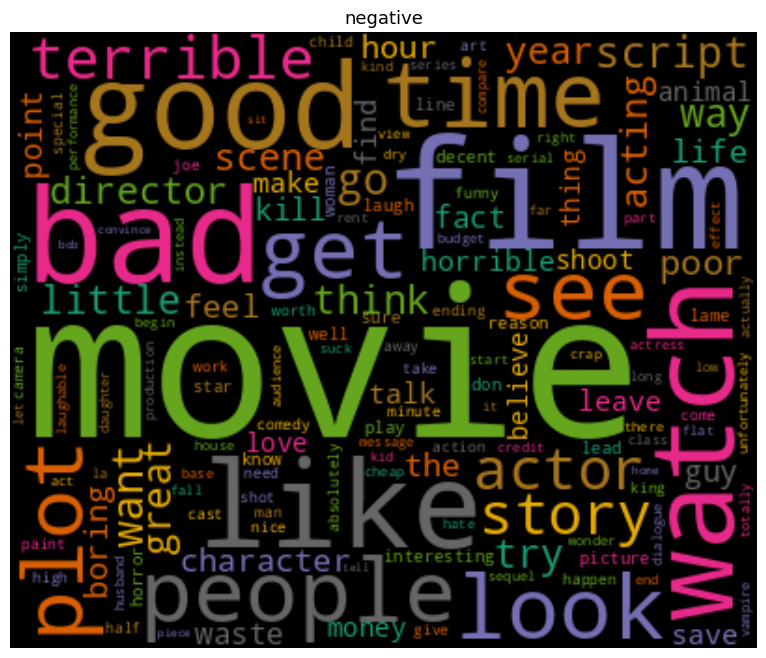

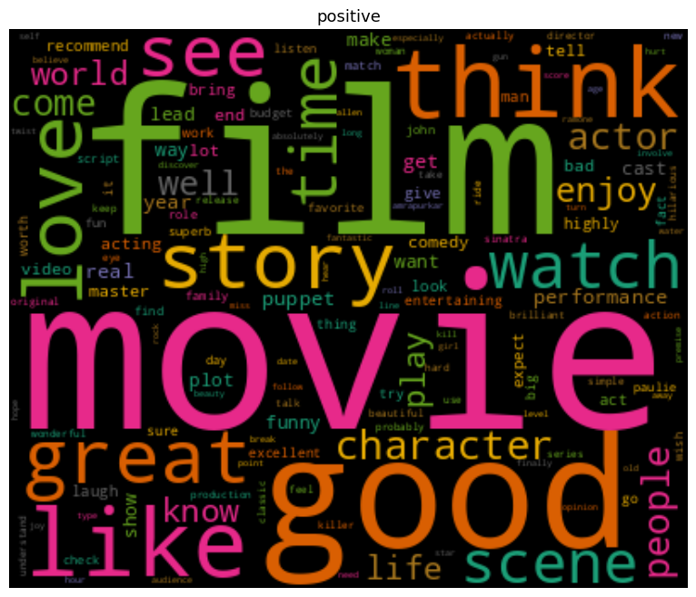

```python
# Importing wordcloud for plotting word clouds and textwrap for wrapping longer text
from wordcloud import WordCloud
from textwrap import wrap

# Function for generating word clouds
def generate_wordcloud(data,title):
  wc = WordCloud(width=400, height=330, max_words=150,colormap="Dark2").generate_from_frequencies(data)
  plt.figure(figsize=(10,8))
  plt.imshow(wc, interpolation='bilinear')
  plt.axis("off")
  plt.title('\n'.join(wrap(title,60)),fontsize=13)
  plt.show()

# Transposing document term matrix
df_dtm=df_dtm.transpose()

# Plotting word cloud for each product
for index,product in enumerate(df_dtm.columns):
  generate_wordcloud(df_dtm[product].sort_values(ascending=False),product)
```

### plot sentiments:

```
Number of each sentiment in train_df :
```

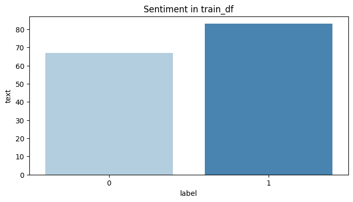

```
Number of each sentiment in test_df :
```

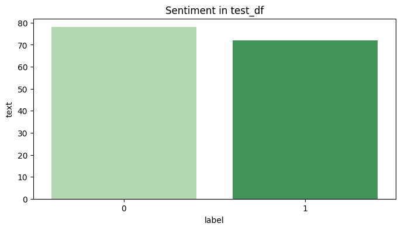

```python
import seaborn as sns

def plot_sentiment(df, title, color):
    temp = df.groupby('label').count()['text'].reset_index().sort_values(by='text',ascending=False)
    plt.figure(figsize=(8,4))
    sns.barplot(x='label', y='text', data=temp, palette=color)
    plt.title(title)
    plt.show()

print("Number of each sentiment in train_df : ")
plot_sentiment(train_df, 'Sentiment in train_df', 'Blues')

print("Number of each sentiment in test_df : ")
plot_sentiment(test_df, 'Sentiment in test_df', 'Greens')
```

### checking readibilty and complexity of textx

```python
!pip install textstat
import textstat
```

```
     ━━━━━━━━━━━━━━━━━━━━━━━━━━━━━━━━━━━━━━━━ 105.1/105.1 kB 4.2 MB/s eta 0:00:00
     ━━━━━━━━━━━━━━━━━━━━━━━━━━━━━━━━━━━━━━━━ 2.1/2.1 MB 43.5 MB/s eta 0:00:00
```

unlabeled_df

```python
def check_complexity_and_readibility(train_df):
  train_df['dale_chall_score']=train_df['lemmatized'].apply(lambda x: textstat.dale_chall_readability_score(x))
  print('Dale Chall Score of positive reviews=>',train_df[train_df['label'] == 1]['dale_chall_score'].mean())
  print('Dale Chall Score of negative reviews=>',train_df[train_df['label'] == 0]['dale_chall_score'].mean())
  print("\n\n")

  train_df['flesh_reading_ease']=train_df['text'].apply(lambda x: textstat.flesch_reading_ease(x))
  print('Flesch Reading Score of positive reviews=>',train_df[train_df['label']==1]['flesh_reading_ease'].mean())
  print('Flesch Reading Score of negative reviews=>',train_df[train_df['label']==0]['flesh_reading_ease'].mean())
  print("\n\n")

  train_df['gunning_fog']=train_df['text'].apply(lambda x: textstat.gunning_fog(x))
  print('Gunning Fog Index of positive reviews=>',train_df[train_df['label']==1]['gunning_fog'].mean())
  print('Gunning Fog Index of negative reviews=>',train_df[train_df['label']==0]['gunning_fog'].mean())
  print("\n\n")

  train_df['text_standard']=train_df['text'].apply(lambda x: textstat.text_standard(x))
  print('Text Standard of positive reviews=>',train_df[train_df['label']==1]['text_standard'].mode())
  print('Text Standard of negative reviews=>',train_df[train_df['label']==0]['text_standard'].mode())
  print("\n\n")

  train_df['reading_time']=train_df['text'].apply(lambda x: textstat.reading_time(x))
  print('Reading Time of upvoted reviews=>',train_df[train_df['label']==1]['reading_time'].mean())
  print('Reading Time of not upvoted reviews=>',train_df[train_df['label']==0]['reading_time'].mean())
  print("\n\n")
```

```python
check_complexity_and_readibility(train_df)
```

```
Dale Chall Score of positive reviews=> 10.559277108433735
Dale Chall Score of negative reviews=> 10.924626865671641



Flesch Reading Score of positive reviews=> 76.15180722891566
Flesch Reading Score of negative reviews=> 75.12194029850748



Gunning Fog Index of positive reviews=> 8.924457831325302
Gunning Fog Index of negative reviews=> 8.809253731343286



Text Standard of positive reviews=> 0    7th and 8th grade
Name: text_standard, dtype: object
Text Standard of negative reviews=> 0    5th and 6th grade
Name: text_standard, dtype: object



Reading Time of upvoted reviews=> 5.782048192771085
Reading Time of not upvoted reviews=> 6.249104477611939
```

```python
def check_complexity_and_readibility_unlabeld(train_df):
  train_df['dale_chall_score']=train_df['lemmatized'].apply(lambda x: textstat.dale_chall_readability_score(x))
  print('Dale Chall Score of reviews=>',train_df['dale_chall_score'].mean())
  print("\n\n")

  train_df['flesh_reading_ease']=train_df['text'].apply(lambda x: textstat.flesch_reading_ease(x))
  print('Flesch Reading Score of reviews=>',train_df['flesh_reading_ease'].mean())
  print("\n\n")

  train_df['gunning_fog']=train_df['text'].apply(lambda x: textstat.gunning_fog(x))
  print('Gunning Fog Index of reviews=>',train_df['gunning_fog'].mean())
  print("\n\n")

  train_df['text_standard']=train_df['text'].apply(lambda x: textstat.text_standard(x))
  print('Text Standard of reviews=>',train_df['text_standard'].mode())
  print("\n\n")

  train_df['reading_time']=train_df['text'].apply(lambda x: textstat.reading_time(x))
  print('Reading Time of upvoted reviews=>',train_df['reading_time'].mean())
  print("\n\n")
```

```python
check_complexity_and_readibility_unlabeld(unlabeled_df)
```

```
Dale Chall Score of reviews=> 10.841005917159764



Flesch Reading Score of reviews=> 74.34245562130178



Gunning Fog Index of reviews=> 9.210493096646942



Text Standard of reviews=> 0    8th and 9th grade
Name: text_standard, dtype: object



Reading Time of upvoted reviews=> 6.344230769230769
```

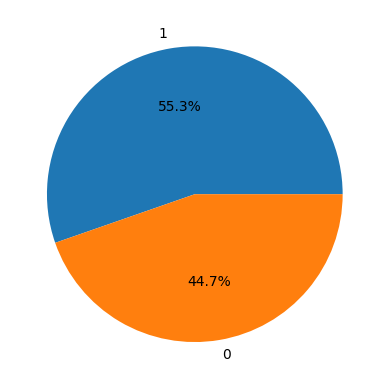

```python
import matplotlib.pyplot as plt
def pie_plot_value_counts(df):
  plt.pie(df['label'].value_counts(), labels=df['label'].unique().tolist(), autopct='%1.1f%%')
  plt.show()
pie_plot_value_counts(train_df)
```

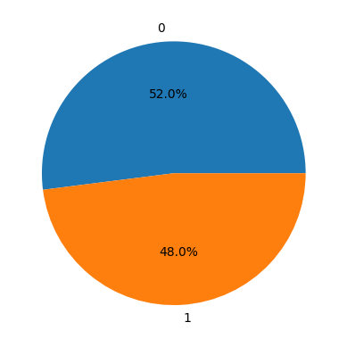

```python
pie_plot_value_counts(test_df)
```

```python
labeled_df = pd.concat([train_df , test_df] , axis = 0)
```

```python
def word_count(text):
    text_list = text.split()
    return len(text_list)

labeled_df['Word_count'] = labeled_df['text'].apply(word_count)
labeled_df.head(10)
```

|  | text | label | embedding | lemmatized | dale_chall_score | flesh_reading_ease | gunning_fog | text_standard | reading_time | Word_count |
| --- | --- | --- | --- | --- | --- | --- | --- | --- | --- | --- |
| 0 | fairly good romantic comedy in which i do not ... | 1 | [-0.0167805497, -0.0395836979, 0.1233159453000... | fairly good romantic comedy think see meg look... | 8.70 | 73.78 | 8.54 | 6th and 7th grade | 4.58 | 72 |
| 1 | "dressed to kill", is one of the best thriller... | 1 | [-0.12526972590000002, 0.10147688540000001, 0.... | " dressed kill " , good thriller . dealing sex... | 11.06 | 78.48 | 9.44 | 8th and 9th grade | 8.48 | 127 |
| 2 | i'm glad that users (as of this date) who like... | 1 | [0.1312361956, 0.0294876788, 0.2328549027, -0.... | glad user ( date ) like movie come forward . u... | 9.02 | 78.69 | 9.72 | 8th and 9th grade | 8.27 | 127 |
| 3 | needed an excuse to get out of the house while... | 0 | [0.1387384981, 0.0460377187, 0.3447172046, -0.... | need excuse house paint dry - leave movie hour... | 8.43 | 81.83 | 6.94 | 6th and 7th grade | 7.48 | 122 |
| 4 | john candy is performance in once upon a crime... | 1 | [0.1606466323, -0.1768193543, 0.35633808370000... | john candy performance crime possibly good . f... | 10.42 | 97.20 | 4.87 | 1st and 2nd grade | 2.86 | 48 |
| 5 | this movie maybe really bad, but it is alot of... | 1 | [0.0058481544000000005, -0.1326265633, 0.18759... | movie maybe bad , alot fun . bad acting poor d... | 9.20 | 82.75 | 7.21 | 5th and 6th grade | 6.01 | 97 |
| 6 | besides being boring, the scenes were oppressi... | 0 | [0.1397939026, -0.021955709900000002, 0.169891... | boring , scene oppressive dark . movie try por... | 11.83 | 84.68 | 8.13 | 5th and 6th grade | 3.25 | 48 |
| 7 | this is exactly the sort of saturday matinee s... | 0 | [0.0405324325, 0.0174655784, 0.1514206231, 0.0... | exactly sort saturday matinee serial love worl... | 11.07 | 79.26 | 7.06 | 4th and 5th grade | 5.44 | 81 |
| 8 | very slick, very pre-hays code, and still very... | 1 | [0.039149038500000004, -0.0511390641, 0.348277... | slick , pre - hay code , sassy . highly recomm... | 12.78 | 82.24 | 8.14 | 6th and 7th grade | 6.60 | 102 |
| 9 | i like this film a lot. it has a wonderful che... | 1 | [-0.1012975574, 0.12617483740000002, 0.0768608... | like film lot . wonderful chemistry actor tell... | 9.87 | 74.49 | 7.43 | 6th and 7th grade | 8.23 | 123 |

```python
labeled_df['mean_word_length'] = labeled_df['text'].map(lambda rev: np.mean([len(word) for word in rev.split()]))
labeled_df.head(10)
```

|  | text | label | embedding | lemmatized | dale_chall_score | flesh_reading_ease | gunning_fog | text_standard | reading_time | Word_count | mean_word_length |
| --- | --- | --- | --- | --- | --- | --- | --- | --- | --- | --- | --- |
| 0 | fairly good romantic comedy in which i do not ... | 1 | [-0.0167805497, -0.0395836979, 0.1233159453000... | fairly good romantic comedy think see meg look... | 8.70 | 73.78 | 8.54 | 6th and 7th grade | 4.58 | 72 | 4.333333 |
| 1 | "dressed to kill", is one of the best thriller... | 1 | [-0.12526972590000002, 0.10147688540000001, 0.... | " dressed kill " , good thriller . dealing sex... | 11.06 | 78.48 | 9.44 | 8th and 9th grade | 8.48 | 127 | 4.543307 |
| 2 | i'm glad that users (as of this date) who like... | 1 | [0.1312361956, 0.0294876788, 0.2328549027, -0.... | glad user ( date ) like movie come forward . u... | 9.02 | 78.69 | 9.72 | 8th and 9th grade | 8.27 | 127 | 4.433071 |
| 3 | needed an excuse to get out of the house while... | 0 | [0.1387384981, 0.0460377187, 0.3447172046, -0.... | need excuse house paint dry - leave movie hour... | 8.43 | 81.83 | 6.94 | 6th and 7th grade | 7.48 | 122 | 4.172131 |
| 4 | john candy is performance in once upon a crime... | 1 | [0.1606466323, -0.1768193543, 0.35633808370000... | john candy performance crime possibly good . f... | 10.42 | 97.20 | 4.87 | 1st and 2nd grade | 2.86 | 48 | 4.062500 |
| 5 | this movie maybe really bad, but it is alot of... | 1 | [0.0058481544000000005, -0.1326265633, 0.18759... | movie maybe bad , alot fun . bad acting poor d... | 9.20 | 82.75 | 7.21 | 5th and 6th grade | 6.01 | 97 | 4.216495 |
| 6 | besides being boring, the scenes were oppressi... | 0 | [0.1397939026, -0.021955709900000002, 0.169891... | boring , scene oppressive dark . movie try por... | 11.83 | 84.68 | 8.13 | 5th and 6th grade | 3.25 | 48 | 4.604167 |
| 7 | this is exactly the sort of saturday matinee s... | 0 | [0.0405324325, 0.0174655784, 0.1514206231, 0.0... | exactly sort saturday matinee serial love worl... | 11.07 | 79.26 | 7.06 | 4th and 5th grade | 5.44 | 81 | 4.567901 |
| 8 | very slick, very pre-hays code, and still very... | 1 | [0.039149038500000004, -0.0511390641, 0.348277... | slick , pre - hay code , sassy . highly recomm... | 12.78 | 82.24 | 8.14 | 6th and 7th grade | 6.60 | 102 | 4.401961 |
| 9 | i like this film a lot. it has a wonderful che... | 1 | [-0.1012975574, 0.12617483740000002, 0.0768608... | like film lot . wonderful chemistry actor tell... | 9.87 | 74.49 | 7.43 | 6th and 7th grade | 8.23 | 123 | 4.552846 |

```python
import nltk
nltk.download('punkt')
import nltk.tokenize
labeled_df['mean_sent_length'] = labeled_df['text'].map(lambda rev: np.mean([len(sent) for sent in nltk.tokenize.sent_tokenize(rev)]))
labeled_df.head(10)
```

|  | text | label | embedding | lemmatized | dale_chall_score | flesh_reading_ease | gunning_fog | text_standard | reading_time | Word_count | mean_word_length | mean_sent_length |
| --- | --- | --- | --- | --- | --- | --- | --- | --- | --- | --- | --- | --- |
| 0 | fairly good romantic comedy in which i do not ... | 1 | [-0.0167805497, -0.0395836979, 0.1233159453000... | fairly good romantic comedy think see meg look... | 8.70 | 73.78 | 8.54 | 6th and 7th grade | 4.58 | 72 | 4.333333 | 75.800000 |
| 1 | "dressed to kill", is one of the best thriller... | 1 | [-0.12526972590000002, 0.10147688540000001, 0.... | " dressed kill " , good thriller . dealing sex... | 11.06 | 78.48 | 9.44 | 8th and 9th grade | 8.48 | 127 | 4.543307 | 99.571429 |
| 2 | i'm glad that users (as of this date) who like... | 1 | [0.1312361956, 0.0294876788, 0.2328549027, -0.... | glad user ( date ) like movie come forward . u... | 9.02 | 78.69 | 9.72 | 8th and 9th grade | 8.27 | 127 | 4.433071 | 85.250000 |
| 3 | needed an excuse to get out of the house while... | 0 | [0.1387384981, 0.0460377187, 0.3447172046, -0.... | need excuse house paint dry - leave movie hour... | 8.43 | 81.83 | 6.94 | 6th and 7th grade | 7.48 | 122 | 4.172131 | 104.166667 |
| 4 | john candy is performance in once upon a crime... | 1 | [0.1606466323, -0.1768193543, 0.35633808370000... | john candy performance crime possibly good . f... | 10.42 | 97.20 | 4.87 | 1st and 2nd grade | 2.86 | 48 | 4.062500 | 39.500000 |
| 5 | this movie maybe really bad, but it is alot of... | 1 | [0.0058481544000000005, -0.1326265633, 0.18759... | movie maybe bad , alot fun . bad acting poor d... | 9.20 | 82.75 | 7.21 | 5th and 6th grade | 6.01 | 97 | 4.216495 | 62.375000 |
| 6 | besides being boring, the scenes were oppressi... | 0 | [0.1397939026, -0.021955709900000002, 0.169891... | boring , scene oppressive dark . movie try por... | 11.83 | 84.68 | 8.13 | 5th and 6th grade | 3.25 | 48 | 4.604167 | 66.250000 |
| 7 | this is exactly the sort of saturday matinee s... | 0 | [0.0405324325, 0.0174655784, 0.1514206231, 0.0... | exactly sort saturday matinee serial love worl... | 11.07 | 79.26 | 7.06 | 4th and 5th grade | 5.44 | 81 | 4.567901 | 63.428571 |
| 8 | very slick, very pre-hays code, and still very... | 1 | [0.039149038500000004, -0.0511390641, 0.348277... | slick , pre - hay code , sassy . highly recomm... | 12.78 | 82.24 | 8.14 | 6th and 7th grade | 6.60 | 102 | 4.401961 | 90.833333 |
| 9 | i like this film a lot. it has a wonderful che... | 1 | [-0.1012975574, 0.12617483740000002, 0.0768608... | like film lot . wonderful chemistry actor tell... | 9.87 | 74.49 | 7.43 | 6th and 7th grade | 8.23 | 123 | 4.552846 | 96.571429 |

## Using TextBlob to calculate sentiment polarity which lies in the range of [-1,1] where 1 means positive sentiment and -1 means a negative sentiment.

```python
import re
from textblob import TextBlob

def preprocess(ReviewText):
    # Remove HTML tags
    ReviewText = ReviewText.str.replace(r'<.*?>', '', regex=True)
    # Remove special characters
    ReviewText = ReviewText.str.replace(r'&.*?;', '', regex=True)
    # Replace non-breaking space with a regular space
    ReviewText = ReviewText.str.replace(r'\xa0', ' ')
    # Convert to lowercase
    ReviewText = ReviewText.str.lower()
    # Remove any remaining punctuation
    ReviewText = ReviewText.str.replace(r'[^\w\s]', '')
    return ReviewText

labeled_df['processed_text'] = preprocess(labeled_df['text'])
labeled_df['Polarity'] = labeled_df['processed_text'].apply(lambda x: TextBlob(x).sentiment.polarity)
print('min polarity : ', labeled_df['Polarity'].min())
print('max polarity : ', labeled_df['Polarity'].max())
```

```
min polarity :  -0.5809523809523809
max polarity :  1.0
```

```python
from sklearn.feature_extraction.text import CountVectorizer

def get_top_ngrams(corpus, ngram_range, stop_words=None, n=None):
    vec = CountVectorizer(stop_words=stop_words, ngram_range=ngram_range).fit(corpus)
    bag_of_words = vec.transform(corpus)

    sum_words = bag_of_words.sum(axis=0)

    words_freq = [(word, sum_words[0, idx]) for word, idx in vec.vocabulary_.items()]
    words_freq = sorted(words_freq, key=lambda x: x[1], reverse=True)

    common_words = words_freq[:n]
    words = []
    freqs = []
    for word, freq in common_words:
        words.append(word)
        freqs.append(freq)

    df = pd.DataFrame({'Word': words, 'Freq': freqs})
    return df
stop_words = None
n = 20
unigrams = get_top_ngrams(labeled_df['processed_text'], (1, 1), stop_words, n)
bigrams = get_top_ngrams(labeled_df['processed_text'], (2, 2), stop_words, n)
trigrams = get_top_ngrams(labeled_df['processed_text'], (3, 3), stop_words, n)
stop_words = 'english'
n = 20
unigrams_st = get_top_ngrams(labeled_df['processed_text'], (1, 1), stop_words, n)
bigrams_st = get_top_ngrams(labeled_df['processed_text'], (2, 2), stop_words, n)
trigrams_st = get_top_ngrams(labeled_df['processed_text'], (3, 3), stop_words, n)
```

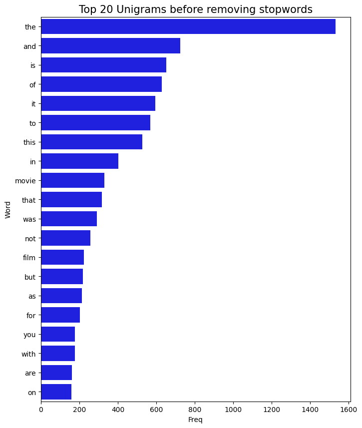

```python
colors = ['blue', 'green', 'red', 'purple', 'yellow']
plt.figure(figsize=(8, 10))
sns.barplot(x='Freq', y='Word', color=colors[0], data=unigrams)
plt.title('Top 20 Unigrams before removing stopwords', size=15)
plt.show()
```

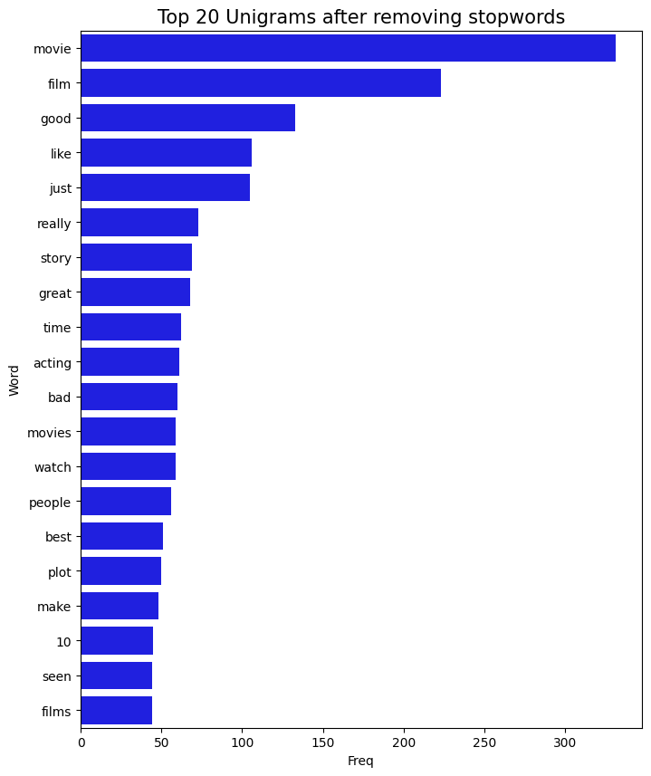

```python
plt.figure(figsize=(8, 10))
sns.barplot(x='Freq', y='Word', color=colors[0], data=unigrams_st)
plt.title('Top 20 Unigrams after removing stopwords', size=15)
plt.show()
```

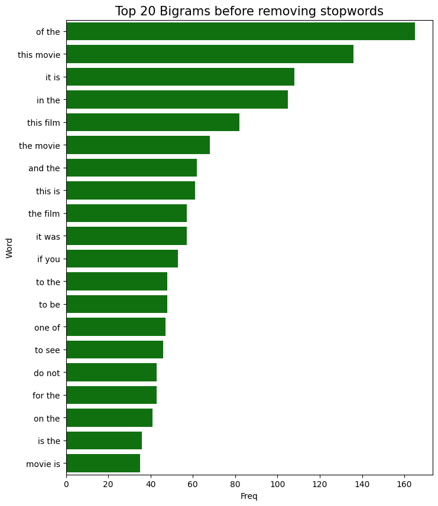

```python
plt.figure(figsize=(8, 10))
sns.barplot(x='Freq', y='Word', color=colors[1], data=bigrams)
plt.title('Top 20 Bigrams before removing stopwords', size=15)
plt.show()
```

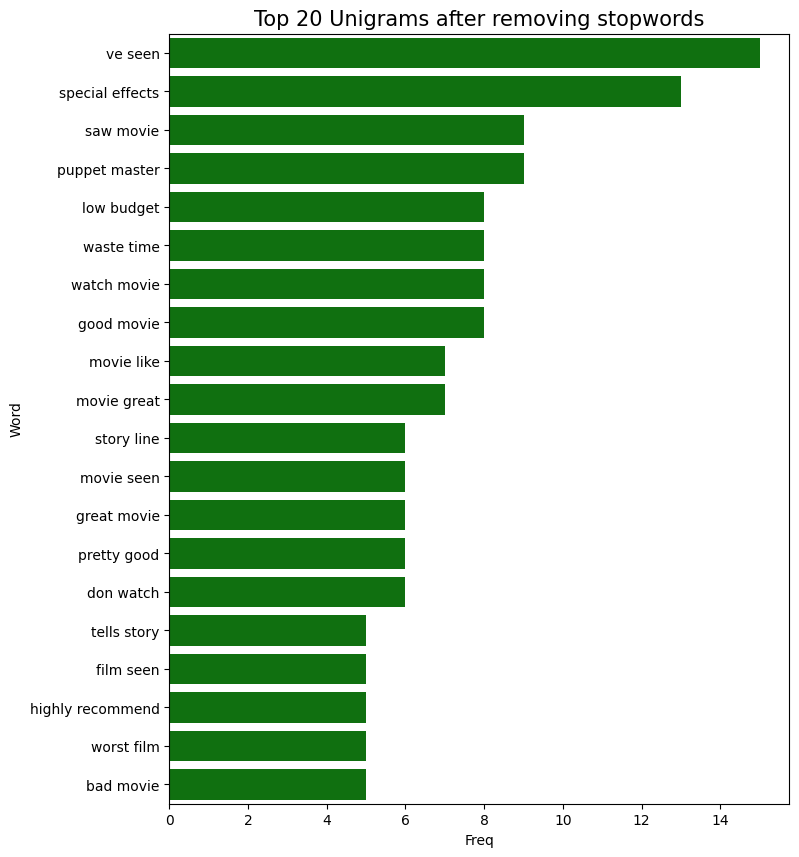

```python
plt.figure(figsize=(8, 10))
sns.barplot(x='Freq', y='Word', color=colors[1], data=bigrams_st)
plt.title('Top 20 Unigrams after removing stopwords', size=15)
plt.show()
```

### Trigrams Distribution

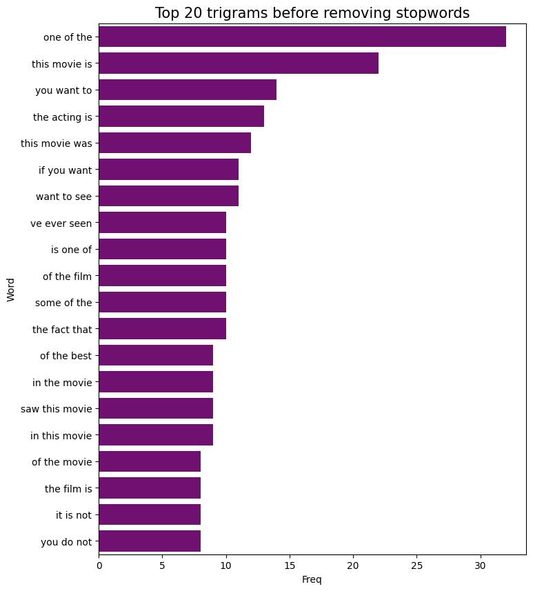

```python
plt.figure(figsize=(8, 10))
sns.barplot(x='Freq', y='Word', color=colors[3], data=trigrams)
plt.title('Top 20 trigrams before removing stopwords', size=15)
plt.show()
```

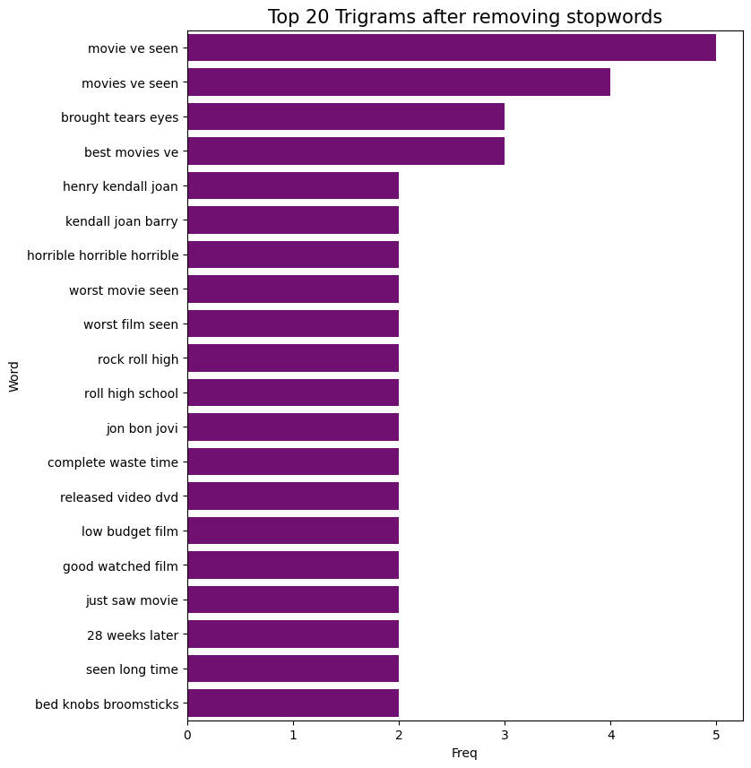

```python
plt.figure(figsize=(8, 10))
sns.barplot(x='Freq', y='Word', color=colors[3], data=trigrams_st)
plt.title('Top 20 Trigrams after removing stopwords', size=15)
plt.show()
```

```python
import nltk
nltk.download('averaged_perceptron_tagger')
import re
from textblob import TextBlob
import pandas as pd


def minimal_preprocess(text):
    text = re.sub(r'<.*?>', '', text)
    text = re.sub(r'&.*?;', '', text)
    text = text.replace('\xa0', ' ')
    return text

labeled_df['cleaned_text'] = labeled_df['text'].apply(minimal_preprocess)
blob = TextBlob(' '.join(labeled_df['cleaned_text']))
pos_df = pd.DataFrame(blob.tags, columns=['word', 'pos'])
top_pos = pos_df['pos'].value_counts()

print(top_pos)
```

```
pos
NN      5671
DT      3346
IN      2918
JJ      2663
RB      2117
NNS     1276
VBZ     1243
VB      1173
PRP     1173
CC      1050
VBD      896
VBP      773
TO       567
VBN      560
VBG      462
CD       379
MD       354
PRP$     353
WRB      181
WP       154
JJS      142
WDT      124
RP       111
JJR       97
POS       85
EX        74
RBR       64
NNP       50
PDT       41
RBS       23
FW        16
UH        16
WP$        1
Name: count, dtype: int64
```

The output you're seeing is a series object from the pandas library. The index of the series represents Part-of-Speech (POS) tags, and the values represent the count of each POS tag in your text data.

- `NN`: Noun, singular or mass
- `DT`: Determiner (e.g., 'the', 'this')
- `IN`: Preposition or subordinating conjunction
- `JJ`: Adjective
- `RB`: Adverb
- `NNS`: Noun, plural
- `VBZ`: Verb, 3rd person singular present
- `PRP`: Personal pronoun (e.g., 'he', 'she')
- `VB`: Verb, base form
- `CC`: Coordinating conjunction (e.g., 'and', 'or')
- `VBD`: Verb, past tense
- `VBP`: Verb, non-3rd person singular present
- `TO`: The word 'to'
- `VBN`: Verb, past participle
- `VBG`: Verb, gerund or present participle
- `CD`: Cardinal number
- `PRP$`: Possessive pronoun (e.g., 'his', 'her')
- `MD`: Modal (e.g., 'could', 'will')
- `WRB`: Wh-adverb (e.g., 'where', 'when')
- `WP`: Wh-pronoun (e.g., 'what', 'who')
- `JJS`: Adjective, superlative
- `POS`: Possessive ending (e.g., 's)
- `WDT`: Wh-determiner (e.g., 'which', 'that')
- `RP`: Particle (e.g., 'up', 'off')
- `JJR`: Adjective, comparative
- `EX`: Existential 'there'
- `RBR`: Adverb, comparative
- `NNP`: Proper noun, singular
- `PDT`: Predeterminer (e.g., 'all', 'both')
- `RBS`: Adverb, superlative
- `UH`: Interjection (e.g., 'oh', 'wow')
- `FW`: Foreign word
- `WP$`: Possessive wh-pronoun (e.g., 'whose')

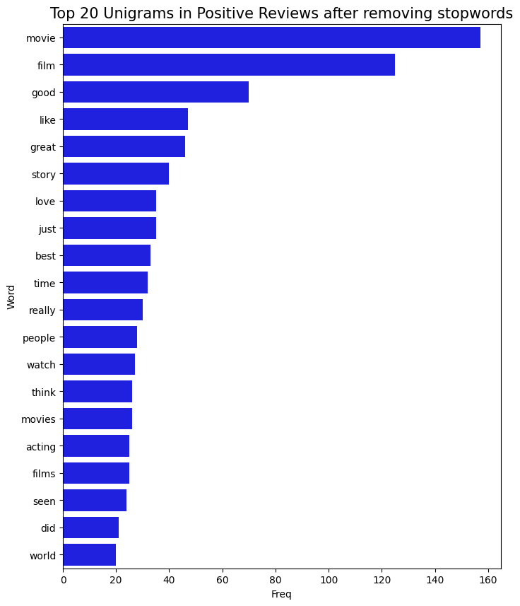

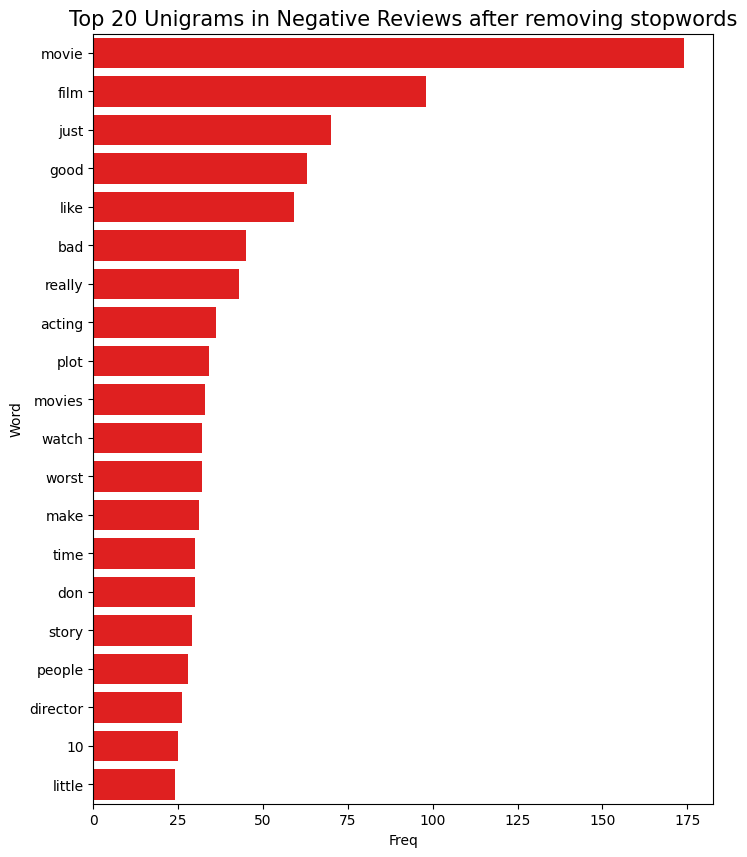

```python
Positive_sent = labeled_df[labeled_df['label'] == 1]
Negative_sent = labeled_df[labeled_df['label'] == 0]

stop_words = 'english'
n = 20

positive_unigrams = get_top_ngrams(Positive_sent['processed_text'], (1, 1), stop_words, n)
negative_unigrams = get_top_ngrams(Negative_sent['processed_text'], (1, 1), stop_words, n)

plt.figure(figsize=(8, 10))
sns.barplot(x='Freq', y='Word', color='blue', data=positive_unigrams)
plt.title('Top 20 Unigrams in Positive Reviews after removing stopwords', size=15)
plt.show()

plt.figure(figsize=(8, 10))
sns.barplot(x='Freq', y='Word', color='red', data=negative_unigrams)
plt.title('Top 20 Unigrams in Negative Reviews after removing stopwords', size=15)
plt.show()
```

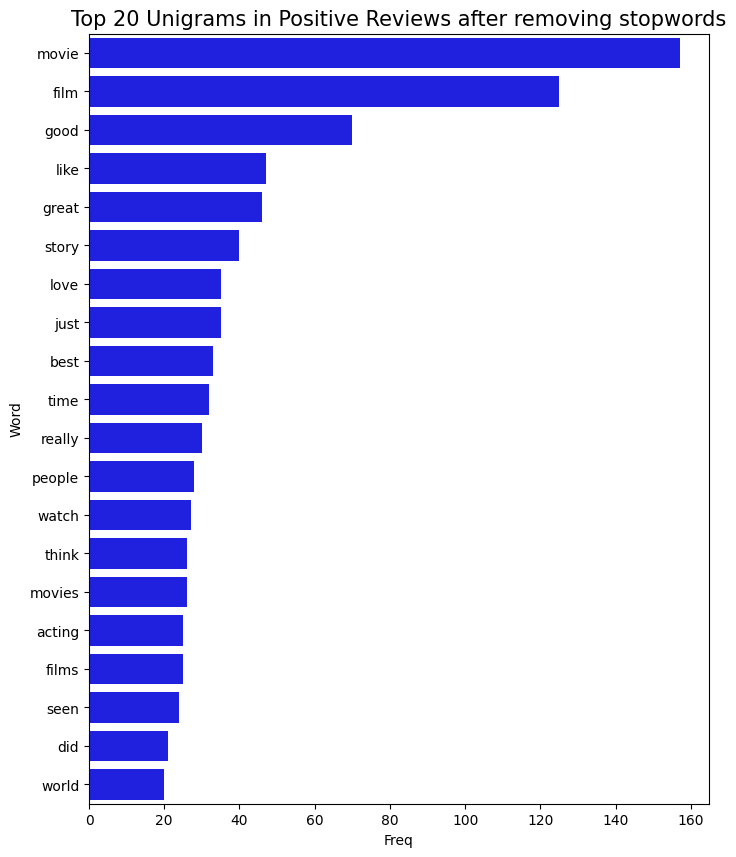

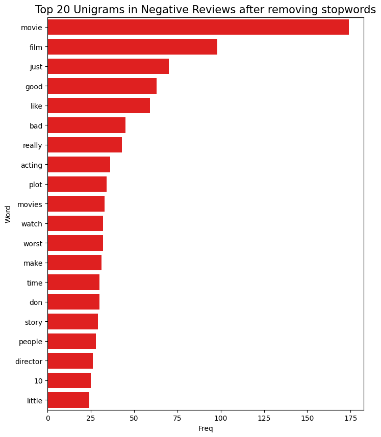

```python
import pandas as pd
import seaborn as sns
import matplotlib.pyplot as plt
from sklearn.feature_extraction.text import CountVectorizer

def get_top_ngrams(corpus, ngram_range, stop_words=None, n=None):
    vec = CountVectorizer(stop_words=stop_words, ngram_range=ngram_range).fit(corpus)
    bag_of_words = vec.transform(corpus)

    sum_words = bag_of_words.sum(axis=0)

    words_freq = [(word, sum_words[0, idx]) for word, idx in vec.vocabulary_.items()]
    words_freq = sorted(words_freq, key=lambda x: x[1], reverse=True)

    common_words = words_freq[:n]
    words = []
    freqs = []
    for word, freq in common_words:
        words.append(word)
        freqs.append(freq)

    df = pd.DataFrame({'Word': words, 'Freq': freqs})
    return df

Positive_sent = labeled_df[labeled_df['label'] == 1]
Negative_sent = labeled_df[labeled_df['label'] == 0]

stop_words = 'english'
n = 20

positive_unigrams = get_top_ngrams(Positive_sent['processed_text'], (1, 1), stop_words, n)
negative_unigrams = get_top_ngrams(Negative_sent['processed_text'], (1, 1), stop_words, n)

plt.figure(figsize=(8, 10))
sns.barplot(x='Freq', y='Word', color='blue', data=positive_unigrams)
plt.title('Top 20 Unigrams in Positive Reviews after removing stopwords', size=15)
plt.show()


plt.figure(figsize=(8, 10))
sns.barplot(x='Freq', y='Word', color='red', data=negative_unigrams)
plt.title('Top 20 Unigrams in Negative Reviews after removing stopwords', size=15)
plt.show()
```

```python
import re

labeled_df['labeled_text_processed'] = labeled_df['text'].map(lambda x: re.sub('[,\.!?]', '', x))
labeled_df['labeled_text_processed'] = labeled_df['labeled_text_processed'].map(lambda x: x.lower())
labeled_df['labeled_text_processed'].head()
```

```
0    fairly good romantic comedy in which i do not ...
1    "dressed to kill" is one of the best thrillers...
2    i'm glad that users (as of this date) who like...
3    needed an excuse to get out of the house while...
4    john candy is performance in once upon a crime...
Name: labeled_text_processed, dtype: object
```

```python
import gensim
from gensim.utils import simple_preprocess

def sent_to_words(sentences):
    for sentence in sentences:
        yield(gensim.utils.simple_preprocess(str(sentence), deacc=True))  # deacc=True removes punctuations

data = labeled_df.labeled_text_processed.values.tolist()
data_words = list(sent_to_words(data))

print(data_words[:1][0][:30])
```

```
['fairly', 'good', 'romantic', 'comedy', 'in', 'which', 'do', 'not', 'think', 've', 'ever', 'seen', 'meg', 'looking', 'any', 'cuter', 'all', 'the', 'players', 'did', 'good', 'job', 'at', 'keeping', 'this', 'lively', 'romp', 'of', 'course', 'in']
```

```python
# Build the bigram and trigram models
bigram = gensim.models.Phrases(data_words, min_count=5, threshold=100) # higher threshold fewer phrases.
trigram = gensim.models.Phrases(bigram[data_words], threshold=100)

# Faster way to get a sentence clubbed as a trigram/bigram
bigram_mod = gensim.models.phrases.Phraser(bigram)
trigram_mod = gensim.models.phrases.Phraser(trigram)
```

```python
!python -m spacy download en_core_web_sm
import spacy

# NLTK Stop words
import nltk
nltk.download('stopwords')
from nltk.corpus import stopwords

stop_words = stopwords.words('english')
stop_words.extend(['from', 'subject', 're', 'edu', 'use'])

# Initialize spacy 'en' model, keeping only tagger component (for efficiency)
nlp = spacy.load("en_core_web_sm", disable=['parser', 'ner'])

# Define functions for stopwords, bigrams, trigrams and lemmatization
def remove_stopwords(texts):
    return [[word for word in simple_preprocess(str(doc)) if word not in stop_words] for doc in texts]

def make_bigrams(texts):
    return [bigram_mod[doc] for doc in texts]

def make_trigrams(texts):
    return [trigram_mod[bigram_mod[doc]] for doc in texts]

def lemmatization(texts, allowed_postags=['NOUN', 'ADJ', 'VERB', 'ADV']):
    """https://spacy.io/api/annotation"""
    texts_out = []
    for sent in texts:
        doc = nlp(" ".join(sent))
        texts_out.append([token.lemma_ for token in doc if token.pos_ in allowed_postags])
    return texts_out
```

[output not shown]

```python
# Remove Stop Words
data_words_nostops = remove_stopwords(data_words)

# Form Bigrams
data_words_bigrams = make_bigrams(data_words_nostops)

# Do lemmatization keeping only noun, adj, vb, adv
data_lemmatized = lemmatization(data_words_bigrams, allowed_postags=['NOUN', 'ADJ', 'VERB', 'ADV'])

print(data_lemmatized[:1][0][:30])
```

```
['fairly', 'good', 'romantic', 'comedy', 'think', 'ever', 'see', 'look', 'cut', 'player', 'good', 'job', 'keep', 'lively', 'course', 'real', 'world', 'genius', 'even', 'glance', 'romantic', 'comediesone', 'totally', 'forget', 'reality', 'good', 'time', 'nice', 'film']
```

```python
import gensim.corpora as corpora

# Create Dictionary
id2word = corpora.Dictionary(data_lemmatized)

# Create Corpus
texts = data_lemmatized

# Term Document Frequency
corpus = [id2word.doc2bow(text) for text in texts]
```

```python
# Build LDA model
lda_model = gensim.models.LdaMulticore(corpus=corpus,
                                       id2word=id2word,
                                       num_topics=10,
                                       random_state=100,
                                       chunksize=100,
                                       passes=10,
                                       per_word_topics=True)
```

```python
from pprint import pprint

# Print the Keyword in the 10 topics
pprint(lda_model.print_topics())
doc_lda = lda_model[corpus]
```

```
[(0,
  '0.022*"film" + 0.013*"watch" + 0.012*"movie" + 0.009*"well" + 0.008*"even" '
  '+ 0.008*"get" + 0.007*"first" + 0.007*"show" + 0.007*"give" + '
  '0.006*"little"'),
 (1,
  '0.021*"movie" + 0.011*"make" + 0.010*"well" + 0.008*"great" + 0.008*"get" + '
  '0.007*"way" + 0.007*"character" + 0.007*"go" + 0.006*"even" + '
  '0.006*"action"'),
 (2,
  '0.046*"movie" + 0.020*"see" + 0.018*"film" + 0.015*"watch" + 0.013*"good" + '
  '0.010*"make" + 0.010*"get" + 0.009*"well" + 0.008*"bad" + 0.008*"time"'),
 (3,
  '0.018*"movie" + 0.017*"bad" + 0.016*"film" + 0.012*"go" + 0.011*"see" + '
  '0.009*"really" + 0.008*"good" + 0.007*"get" + 0.007*"think" + 0.007*"find"'),
 (4,
  '0.022*"film" + 0.016*"make" + 0.012*"movie" + 0.010*"good" + 0.010*"act" + '
  '0.008*"time" + 0.008*"think" + 0.007*"really" + 0.007*"see" + '
  '0.007*"woman"'),
 (5,
  '0.034*"movie" + 0.028*"good" + 0.013*"film" + 0.010*"story" + 0.008*"see" + '
  '0.008*"make" + 0.007*"well" + 0.007*"play" + 0.007*"even" + 0.006*"also"'),
 (6,
  '0.019*"film" + 0.010*"see" + 0.008*"actor" + 0.008*"even" + 0.006*"story" + '
  '0.006*"work" + 0.006*"good" + 0.005*"life" + 0.005*"act" + 0.005*"play"'),
 (7,
  '0.016*"movie" + 0.010*"good" + 0.007*"bore" + 0.006*"film" + 0.006*"well" + '
  '0.006*"always" + 0.006*"find" + 0.005*"act" + 0.005*"back" + 0.005*"give"'),
 (8,
  '0.025*"film" + 0.021*"movie" + 0.010*"make" + 0.009*"see" + 0.008*"get" + '
  '0.008*"good" + 0.008*"watch" + 0.007*"actor" + 0.007*"game" + 0.006*"even"'),
 (9,
  '0.019*"film" + 0.017*"movie" + 0.012*"time" + 0.011*"bad" + 0.009*"make" + '
  '0.008*"even" + 0.008*"funny" + 0.007*"good" + 0.007*"really" + '
  '0.007*"life"')]
```

```python
from gensim.models import CoherenceModel

# Compute Coherence Score
coherence_model_lda = CoherenceModel(model=lda_model, texts=data_lemmatized, dictionary=id2word, coherence='c_v')
coherence_lda = coherence_model_lda.get_coherence()
print('Coherence Score: ', coherence_lda)
```

```
Coherence Score:  0.2913117312540693
```

```python
from gensim.models import CoherenceModel, LdaMulticore
import multiprocessing

def compute_coherence_values(corpus, dictionary, k, a, b, workers=None):
    """
    Compute coherence values for the given parameters using LDA Multicore model.

    Parameters:
    - corpus: Corpus for LDA
    - dictionary: Dictionary for LDA
    - k: Number of topics
    - a: Alpha parameter
    - b: Beta parameter
    - texts: Preprocessed texts for CoherenceModel
    - workers: Number of worker threads (None uses all available cores)

    Returns:
    - coherence: Coherence score
    """
    # Set the number of workers (None will use all available cores)
    if workers is None:
        workers = multiprocessing.cpu_count()

    lda_model = LdaMulticore(corpus=corpus,
                             id2word=dictionary,
                             num_topics=k,
                             random_state=100,
                             chunksize=100,  # Adjust as needed
                             passes=10,
                             alpha=a,
                             eta=b,
                             workers=workers)

    coherence_model_lda = CoherenceModel(model=lda_model, texts=data_lemmatized, dictionary=id2word, coherence='c_v')
    coherence = coherence_model_lda.get_coherence()

    return coherence
```

# **2. Feature Engineering**

```python
train_df.head()
```

|  | text | label | embedding | lemmatized | dale_chall_score | flesh_reading_ease | gunning_fog | text_standard | reading_time |
| --- | --- | --- | --- | --- | --- | --- | --- | --- | --- |
| 0 | fairly good romantic comedy in which i do not ... | 1 | [-0.0167805497, -0.0395836979, 0.1233159453000... | fairly good romantic comedy think see meg look... | 8.70 | 73.78 | 8.54 | 6th and 7th grade | 4.58 |
| 1 | "dressed to kill", is one of the best thriller... | 1 | [-0.12526972590000002, 0.10147688540000001, 0.... | " dressed kill " , good thriller . dealing sex... | 11.06 | 78.48 | 9.44 | 8th and 9th grade | 8.48 |
| 2 | i'm glad that users (as of this date) who like... | 1 | [0.1312361956, 0.0294876788, 0.2328549027, -0.... | glad user ( date ) like movie come forward . u... | 9.02 | 78.69 | 9.72 | 8th and 9th grade | 8.27 |
| 3 | needed an excuse to get out of the house while... | 0 | [0.1387384981, 0.0460377187, 0.3447172046, -0.... | need excuse house paint dry - leave movie hour... | 8.43 | 81.83 | 6.94 | 6th and 7th grade | 7.48 |
| 4 | john candy is performance in once upon a crime... | 1 | [0.1606466323, -0.1768193543, 0.35633808370000... | john candy performance crime possibly good . f... | 10.42 | 97.20 | 4.87 | 1st and 2nd grade | 2.86 |

```python
import matplotlib.pyplot as plt
from sklearn.decomposition import PCA
from sklearn.preprocessing import StandardScaler
import numpy as np
```

```python
pca = PCA()
pca.fit(np.array(train_df['embedding'].tolist()))
explained_variance = pca.explained_variance_ratio_
cumulative_variance = np.cumsum(explained_variance)
```

```python
!pip install kneed
```

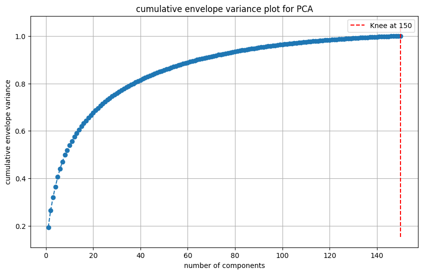

```
PCA 150
```

```python
from kneed import KneeLocator


knee = KneeLocator(range(1, len(cumulative_variance) + 1), cumulative_variance, curve='convex', direction='increasing')

plt.figure(figsize=(10, 6))
plt.plot(range(1, len(cumulative_variance) + 1), cumulative_variance, marker='o', linestyle='--')
plt.vlines(knee.knee, plt.ylim()[0], plt.ylim()[1], linestyles='dashed', colors='r', label=f'Knee at {knee.knee}')
plt.xlabel('number of components')
plt.ylabel('cumulative envelope variance')
plt.title('cumulative envelope variance plot for PCA')
plt.legend()
plt.grid()
plt.show()

print(f"PCA {knee.knee}")
```

```python
pca = PCA(n_components=150)
pca.fit(np.array(train_df['embedding'].tolist()))

train_reduced = pca.transform(np.array(train_df['embedding'].tolist()))

print("Shape of original embeddings:", np.array(train_df['embedding'].tolist()).shape)
print("Shape of reduced embeddings:", train_reduced.shape)
```

```
Shape of original embeddings: (150, 768)
Shape of reduced embeddings: (150, 150)
```

```python
unlabeled_reduced = pca.transform(np.array(unlabeled_df['embedding'].tolist()))

print("Shape of original embeddings:", np.array(unlabeled_df['embedding'].tolist()).shape)
print("Shape of reduced embeddings:", unlabeled_reduced.shape)
```

```
Shape of original embeddings: (1014, 768)
Shape of reduced embeddings: (1014, 150)
```

```python
test_reduced = pca.transform(np.array(test_df['embedding'].tolist()))

print("Shape of original embeddings:", np.array(test_df['embedding'].tolist()).shape)
print("Shape of reduced embeddings:", test_reduced.shape)
```

```
Shape of original embeddings: (150, 768)
Shape of reduced embeddings: (150, 150)
```

```python
import pickle
```

```python
with open('/content/drive/MyDrive/sb_llm_0shot.pkl', 'rb') as file:

    # Call load method to deserialze
    labels_aug_df = pickle.load(file)

    print(len(labels_aug_df))
```

```
1014
```

## **3. Semi-Supervised**

## Unsupervised label generation

### 3.1.1 **`Random Forest`**

**Random Forest** **Summary**:

- Random Forest is an ensemble learning method that constructs multiple decision trees during training and outputs the mode of the classes (classification) or mean prediction (regression) of the individual trees.
- It reduces the risk of overfitting compared to individual decision trees by averaging multiple trees.

**Use Case**:

- Suitable for both classification and regression tasks.
- Commonly used in applications like credit scoring, fraud detection, and medical diagnosis where the model needs to be robust and generalize well to unseen data.

**KMeans** **Summary**:

- KMeans is an unsupervised learning algorithm that partitions the dataset into K clusters based on feature similarity.
- It iteratively assigns data points to the nearest cluster center and then updates the cluster centers based on the mean of the assigned points.

**Use Case**:

- Often used in market segmentation, image compression, and document clustering.
- Effective when the number of clusters is known a priori and the clusters are approximately spherical.

**K-Nearest Neighbors (KNN)** **Summary**:

- KNN is a simple, instance-based learning algorithm where a data point is classified based on the majority class among its K nearest neighbors.
- It is non-parametric and lazy, meaning it makes decisions based on the entire dataset without any explicit training phase.

**Use Case**:

- Useful for classification and regression tasks, especially when the decision boundary is irregular.
- Applied in recommendation systems, handwriting recognition, and anomaly detection.

```python
from sklearn.cluster import KMeans
from sklearn.neighbors import KNeighborsClassifier
from sklearn.ensemble import RandomForestClassifier
from sklearn.metrics import classification_report
from sklearn.model_selection import train_test_split

all_embeddings_pca = np.vstack((train_reduced, unlabeled_reduced))

kmeans = KMeans(n_clusters=2, random_state=42)
clusters = kmeans.fit_predict(all_embeddings_pca)

labeled_clusters = clusters[:len(train_df)]
unlabeled_clusters = clusters[len(train_df):]

unlabeled_df['cluster'] = unlabeled_clusters
```

```python
from sklearn.metrics import confusion_matrix
import matplotlib.patches as mpatches
def make_confusion_matrix(real_labels , pred_labels ):
    cm = confusion_matrix(real_labels, pred_labels)
    # Create a heatmap
    sns.set(font_scale=1.4)
    plt.figure(figsize=(5, 3))
    sns.heatmap(cm, annot=True, fmt="d", cmap = "RdYlGn", cbar=False)
    plt.xlabel("Predicted Labels")
    plt.ylabel("True Labels")
    plt.title("Confusion Matrix")
    plt.show()
    return cm

#%% Scoring function

def scoring(cm ):
    col_sum = [cm[0][i] + cm[1][i]  for i in range(2)]
    precision = [cm[i][i]/sum(cm[i]) for i in range(0,2)]
    recalls = [cm[i][i] / col_sum[i] for i in range(2)]
    F1_score = [(2*precision[i]*recalls[i])/ (precision[i] + recalls[i]) for i in range(2)]
    accuracy = sum(cm[i][i] for i in range(2))/sum(sum(cm))
    plt.clf()
    plt.figure(figsize=(5, 3))
    plt.scatter([0,1], precision)
    plt.scatter([0,1], recalls)
    plt.scatter([0,1], F1_score)
    plt.grid()
    plt.xlabel("class")
    plt.ylabel("metric")
    blue_patch = mpatches.Patch(color='blue',label='precision')
    orange_patch = mpatches.Patch(color='orange',label='F1_score')
    green_patch = mpatches.Patch(color='green',label='recalls')
    plt.legend(handles=[blue_patch,orange_patch,green_patch])

    # Adding the exact values on the plot
    for i in range(2):
        plt.text(i, precision[i], f'{precision[i]:.2f}', ha='center', va='bottom')
        plt.text(i, recalls[i], f'{recalls[i]:.2f}', ha='center', va='bottom')
        plt.text(i, F1_score[i], f'{F1_score[i]:.2f}', ha='center', va='bottom')
    plt.xticks([0, 1])
    plt.show()



    print(f"Precision: {precision[0]:.2f}")
    print(f"Recall: {recalls[0]:.2f}")
    print(f"F1 Score: {F1_score[0]:.2f}")
    print(f"Accurcy: {accuracy:.2f}")

    weighted_average = sum(F1_score)/2
    micro_average = (sum(cm[i][i] for i in range(2)) / sum(sum(cm))) + (sum(cm[i][i] for i in range(2)) / sum(sum(cm))) / 2
    macro_average = sum(F1_score)/2
    print("micro average: " + str(micro_average))
    print("weighted_average: " + str(weighted_average))
    print("macro average: " + str(macro_average))
    print("accuract: " + str(accuracy))
```

```
Fitting 5 folds for each of 27 candidates, totalling 135 fits
```

```
Best Hyperparameters:  {'bootstrap': True, 'max_depth': 20, 'max_features': 'auto', 'n_estimators': 200}
```

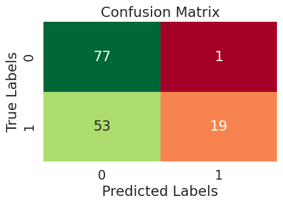

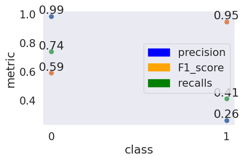

```
Precision: 0.99
Recall: 0.59
F1 Score: 0.74
Accurcy: 0.64
micro average: 0.96
weighted_average: 0.5767140468227425
macro average: 0.5767140468227425
accuract: 0.64
              precision    recall  f1-score   support

           0       0.59      0.99      0.74        78
           1       0.95      0.26      0.41        72

    accuracy                           0.64       150
   macro avg       0.77      0.63      0.58       150
weighted avg       0.76      0.64      0.58       150
```

```python
import numpy as np
from sklearn.ensemble import RandomForestClassifier
from sklearn.model_selection import GridSearchCV
def propagate_labels(labeled_embeddings, labeled_labels, unlabeled_embeddings):
    knn = KNeighborsClassifier(n_neighbors=2)  # Using 5-NN for label propagation
    knn.fit(labeled_embeddings, labeled_labels)
    propagated_labels = knn.predict(unlabeled_embeddings)
    return propagated_labels

propagated_labels = propagate_labels(train_reduced, train_df['label'], unlabeled_reduced)
unlabeled_df['label'] = propagated_labels

combined_df = pd.concat([train_df, unlabeled_df], ignore_index=True)

param_grid = {
    'n_estimators': [50, 100, 200],
    'max_features': ['auto', 'sqrt', 'log2'],
    'max_depth': [5, 10 ,20],
    'bootstrap': [True]
}

classifier = RandomForestClassifier(random_state=42)
grid_search = GridSearchCV(estimator=classifier, param_grid=param_grid,
                           cv=5, n_jobs=-1, verbose=2)

combined_data = np.vstack((train_reduced, unlabeled_reduced))
grid_search.fit(combined_data, combined_df['label'])
best_classifier = grid_search.best_estimator_
test_predictions = best_classifier.predict(test_reduced)
print("Best Hyperparameters: ", grid_search.best_params_)

scoring(make_confusion_matrix(test_df['label'], test_predictions))
print(classification_report(test_df['label'], test_predictions))
```

### **GradientBoostingClassifier**

```python
from sklearn.ensemble import GradientBoostingClassifier
from sklearn.metrics import classification_report
from sklearn.model_selection import GridSearchCV
from scipy.spatial.distance import cdist

# Combine labeled and unlabeled data
all_embeddings = np.vstack((train_df['embedding'].tolist(), unlabeled_df['embedding'].tolist()))
all_labels = np.hstack((train_df['label'].values, [-1] * len(unlabeled_df)))  # -1 for unlabeled

# Store the length of train data for separation later
n_labeled = len(train_df)
n_unlabeled = len(unlabeled_df)

n_clusters = 10

kmeans = KMeans(n_clusters=n_clusters, random_state=42)
kmeans.fit(all_embeddings)
```

```
KMeans(n_clusters=10, random_state=42)
```

```python
clusters = kmeans.labels_


cluster_labels = {}
for cluster in range(n_clusters):
    mask = (clusters[:n_labeled] == cluster)
    if np.sum(mask) > 0:
        majority_label = np.bincount(all_labels[:n_labeled][mask]).argmax()
        cluster_labels[cluster] = majority_label


unlabeled_embeddings = all_embeddings[n_labeled:]
distances = cdist(unlabeled_embeddings, kmeans.cluster_centers_, 'euclidean')

closest_distances = np.min(distances, axis=1)
closest_clusters = np.argmin(distances, axis=1)

# Select most confident points (smallest distances to centroids)
choosed_samples_number = 500
sorted_indices = np.argsort(closest_distances)[:choosed_samples_number]

# Assign labels to the selected unlabeled data based on cluster assignment
propagated_labels = np.array([cluster_labels[closest_clusters[idx]] for idx in sorted_indices])


selected_unlabeled_df = unlabeled_df.iloc[sorted_indices].copy()
selected_unlabeled_df['label'] = propagated_labels


combined_df = pd.concat([train_df, selected_unlabeled_df])
```

```python
# Extract features and labels
X_train = np.vstack(combined_df['embedding'].tolist())
y_train = combined_df['label'].values

X_test = np.vstack(test_df['embedding'].tolist())
y_test = test_df['label'].values


classifier = GradientBoostingClassifier(random_state=42)

param_grid = {
    'n_estimators': [ 200],
    'learning_rate': [ 0.2],
    'max_depth': [ 5]
}

grid_search = GridSearchCV(classifier, param_grid, cv=5, scoring='precision')
grid_search.fit(X_train, y_train)


best_classifier = grid_search.best_estimator_


best_classifier.fit(X_train, y_train)


y_pred = best_classifier.predict(X_test)
```

Semi-supervised result by means of labeld and 500 most confidenced unlabeld data that we generated by unsupervised methods

```
GradientBoostingClassifier(learning_rate=0.2, max_depth=5, n_estimators=200,
                           random_state=42)
              precision    recall  f1-score   support

     Class 0       0.74      0.73      0.74        78
     Class 1       0.71      0.72      0.72        72

    accuracy                           0.73       150
   macro avg       0.73      0.73      0.73       150
weighted avg       0.73      0.73      0.73       150
```

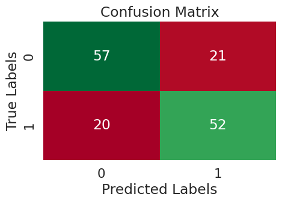

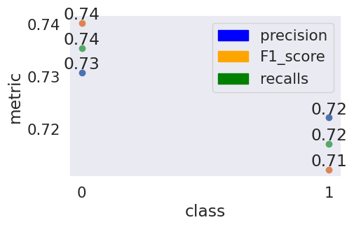

```
Precision: 0.73
Recall: 0.74
F1 Score: 0.74
Accurcy: 0.73
micro average: 1.09
weighted_average: 0.7263626251390434
macro average: 0.7263626251390434
accuract: 0.7266666666666667
```

```python
# Evaluate
print(best_classifier)
print(classification_report(y_test, y_pred, target_names=["Class 0", "Class 1"]))
cm = make_confusion_matrix(y_test, y_pred)
scoring(cm)
```

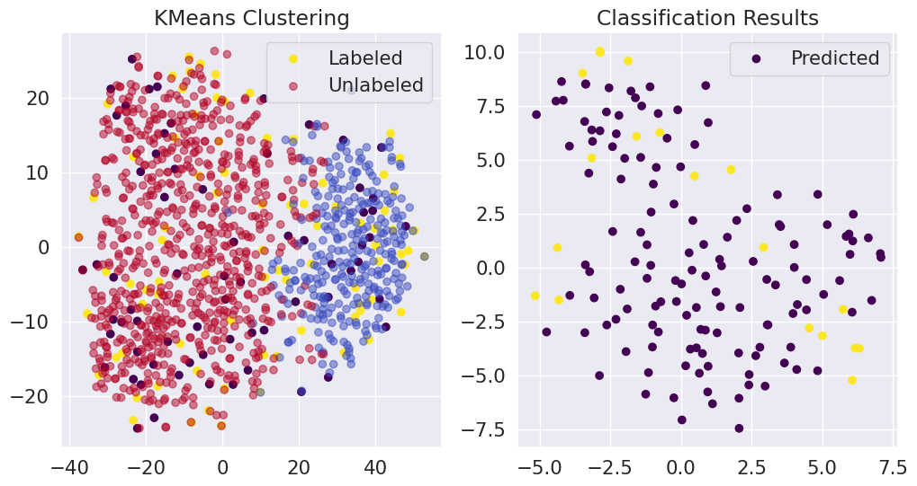

```python
from sklearn.neighbors import KNeighborsClassifier
from sklearn.ensemble import RandomForestClassifier
from sklearn.metrics import classification_report
from sklearn.manifold import TSNE

tsne = TSNE(n_components=2, random_state=42)
all_embeddings_tsne = tsne.fit_transform(all_embeddings_pca)

labeled_embeddings_tsne = all_embeddings_tsne[:len(train_df)]
unlabeled_embeddings_tsne = all_embeddings_tsne[len(train_df):]

plt.figure(figsize=(12, 6))
plt.subplot(1, 2, 1)
plt.scatter(labeled_embeddings_tsne[:, 0], labeled_embeddings_tsne[:, 1], c=train_df['label'], cmap='viridis', label='Labeled')
plt.scatter(unlabeled_embeddings_tsne[:, 0], unlabeled_embeddings_tsne[:, 1], c=unlabeled_df['cluster'], cmap='coolwarm', alpha=0.5, label='Unlabeled')
plt.title('KMeans Clustering')
plt.legend()

test_embeddings_tsne = tsne.fit_transform(test_reduced)
plt.subplot(1, 2, 2)
plt.scatter(test_embeddings_tsne[:, 0], test_embeddings_tsne[:, 1], c=test_predictions, cmap='viridis', label='Predicted')
plt.title('Classification Results')
plt.legend()

plt.show()
```

### `3.1.2 Random Forest (only consider labled data for trainig)`

```
Fitting 5 folds for each of 27 candidates, totalling 135 fits
```

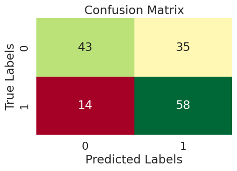

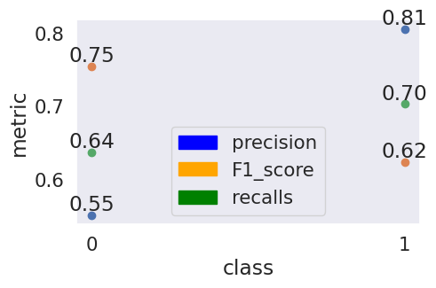

```
Precision: 0.55
Recall: 0.75
F1 Score: 0.64
Accurcy: 0.67
micro average: 1.01
weighted_average: 0.67003367003367
macro average: 0.67003367003367
accuract: 0.6733333333333333
Fitting 5 folds for each of 27 candidates, totalling 135 fits
```

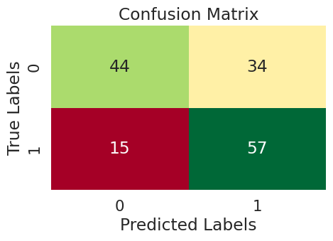

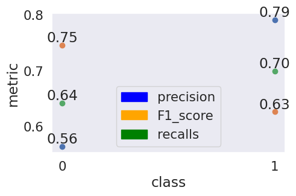

```
Precision: 0.56
Recall: 0.75
F1 Score: 0.64
Accurcy: 0.67
micro average: 1.01
weighted_average: 0.6708611347454212
macro average: 0.6708611347454212
accuract: 0.6733333333333333
```

```python
import numpy as np
import matplotlib.pyplot as plt
import seaborn as sns
from sklearn.decomposition import PCA
from sklearn.ensemble import RandomForestClassifier
from sklearn.metrics import accuracy_score, precision_score, recall_score, confusion_matrix
from sklearn.model_selection import GridSearchCV

# Assuming train_df and test_df are your datasets
X_train = np.array(train_df['embedding'].tolist())
y_train = train_df['label'].values
X_test = np.array(test_df['embedding'].tolist())
y_test = test_df['label'].values

# Initialize PCA and RandomForestClassifier
pca = PCA(n_components=150)
rf_model = RandomForestClassifier(random_state=0)

# Apply PCA
X_train_pca = pca.fit_transform(X_train)
X_test_pca = pca.transform(X_test)

# Initialize GridSearchCV
grid_search = GridSearchCV(estimator=rf_model, param_grid=param_grid, cv=5, n_jobs=-1, verbose=2)

# Fit GridSearchCV to the data
grid_search.fit(X_train_pca, y_train)

# Get the best estimator
best_classifier = grid_search.best_estimator_

# Predict on the test data
y_pred = best_classifier.predict(X_test_pca)

# Confusion matrix and scoring
cm = make_confusion_matrix(y_test, y_pred)
scoring(cm)

# Repeat with PCA n_components=80
pca = PCA(n_components=80)
X_train_pca = pca.fit_transform(X_train)
X_test_pca = pca.transform(X_test)

# Fit GridSearchCV to the data
grid_search.fit(X_train_pca, y_train)

# Get the best estimator
best_classifier = grid_search.best_estimator_

# Predict on the test data
y_pred = best_classifier.predict(X_test_pca)

# Confusion matrix and scoring
cm = make_confusion_matrix(y_test, y_pred)
scoring(cm)
```

### 3.2 `Logistic Regression`

**Summary**:

- Logistic Regression is a linear model used for binary classification. It estimates the probability that a given input point belongs to a particular class.
- Uses the logistic sigmoid function to map predicted values to probabilities.

**Use Case**:

- Widely used in medical diagnosis (e.g., predicting the probability of a disease), credit scoring, and binary outcome prediction problems.
- Suitable for situations where the relationship between the features and the target variable is linear.

```python
import numpy as np
import matplotlib.pyplot as plt
import seaborn as sns
from sklearn.decomposition import PCA
from sklearn.cluster import KMeans
from sklearn.linear_model import LogisticRegression
from sklearn.metrics import accuracy_score, confusion_matrix
from sklearn.model_selection import GridSearchCV

# Prepare the data
X_train = np.array(train_df['embedding'].tolist())
y_train = train_df['label'].values
X_test = np.array(test_df['embedding'].tolist())
y_test = test_df['label'].values
X_unlabeled = np.array(unlabeled_df['embedding'].tolist())

# Apply PCA to reduce dimensionality to 80 components
pca = PCA(n_components=80)
X_train_pca = pca.fit_transform(X_train)
X_test_pca = pca.transform(X_test)
X_unlabeled_pca = pca.transform(X_unlabeled)

# Cluster the training data
kmeans = KMeans(n_clusters=2, random_state=0)
kmeans.fit(X_train_pca)

# Predict clusters for the unlabeled data
unlabeled_clusters = kmeans.predict(X_unlabeled_pca)

# Determine majority label for each cluster
cluster_labels = {i: [] for i in range(2)}
for label, cluster in zip(y_train, kmeans.labels_):
    cluster_labels[cluster].append(label)

majority_labels = {cluster: max(set(labels), key=labels.count) for cluster, labels in cluster_labels.items()}

# Propagate majority labels to unlabeled data
y_unlabeled_propagated = [majority_labels[cluster] for cluster in unlabeled_clusters]

# Combine labeled and unlabeled data
X_combined = np.vstack((X_train_pca, X_unlabeled_pca))
y_combined = np.concatenate((y_train, y_unlabeled_propagated))

# Define the parameter grid for the grid search
param_grid = {
    'C': [0.1, 1.0, 10.0],
    'solver': ['lbfgs', 'liblinear']
}

# Initialize GridSearchCV
log_reg = LogisticRegression(random_state=0)
grid_search = GridSearchCV(estimator=log_reg, param_grid=param_grid, cv=5, n_jobs=-1, verbose=2)

# Train Logistic Regression on combined data with grid search
grid_search.fit(X_combined, y_combined)

# Get the best estimator
best_log_reg = grid_search.best_estimator_

# Predict on the test data
y_pred = best_log_reg.predict(X_test_pca)

cm = make_confusion_matrix(y_test, y_pred)
scoring(cm)
```

```
Fitting 5 folds for each of 6 candidates, totalling 30 fits
```

```
WARNING:matplotlib.text:posx and posy should be finite values
WARNING:matplotlib.text:posx and posy should be finite values
WARNING:matplotlib.text:posx and posy should be finite values
WARNING:matplotlib.text:posx and posy should be finite values
```

```
Precision: 0.00
Recall: nan
F1 Score: nan
Accurcy: 0.48
micro average: 0.72
weighted_average: nan
macro average: nan
accuract: 0.48
```

once we applied PCA to reduce dimensionality to 150 components and once we reduced components to 80. but accuracy did not change!!

### 3.3 `SVM ( with different kernels)`

**Summary**:

- SVM is a supervised learning algorithm used for classification and regression. It finds the hyperplane that best separates the classes in the feature space.
- SVM can use different kernel functions (linear, polynomial, RBF) to handle non-linear classification problems.

**Use Case**:

- Effective in high-dimensional spaces and situations where the number of dimensions exceeds the number of samples.
- Commonly used in text categorization, image classification, and bioinformatics.

```python
from sklearn.svm import SVC
from sklearn.metrics import accuracy_score

X_train = np.array(train_df['embedding'].tolist())
y_train = train_df['label'].values
X_test = np.array(test_df['embedding'].tolist())
y_test = test_df['label'].values
X_unlabeled = np.array(unlabeled_df['embedding'].tolist())

pca = PCA(n_components=150)
X_train_pca = pca.fit_transform(X_train)
X_test_pca = pca.transform(X_test)
X_unlabeled_pca = pca.transform(X_unlabeled)

kmeans = KMeans(n_clusters=2, random_state=0)
kmeans.fit(X_train_pca)

unlabeled_clusters = kmeans.predict(X_unlabeled_pca)


cluster_labels = {i: [] for i in range(2)}
for label, cluster in zip(y_train, kmeans.labels_):
    cluster_labels[cluster].append(label)

majority_labels = {cluster: max(set(labels), key=labels.count) for cluster, labels in cluster_labels.items()}
y_unlabeled_propagated = [majority_labels[cluster] for cluster in unlabeled_clusters]


X_combined = np.vstack((X_train_pca, X_unlabeled_pca))
y_combined = np.concatenate((y_train, y_unlabeled_propagated))

# Train SVM models with different kernels and evaluate
kernels = ['linear', 'rbf', 'poly']
for kernel in kernels:
    svm = SVC(kernel=kernel, random_state=0)
    svm.fit(X_combined, y_combined)
    y_pred = svm.predict(X_test_pca)
    accuracy = accuracy_score(y_test, y_pred)
    print(f"Accuracy with {kernel} kernel: {accuracy:.4f}")
    cm = make_confusion_matrix(y_test, y_pred)
    scoring(cm)
```

```
Accuracy with linear kernel: 0.4800
```

```
WARNING:matplotlib.text:posx and posy should be finite values
WARNING:matplotlib.text:posx and posy should be finite values
WARNING:matplotlib.text:posx and posy should be finite values
WARNING:matplotlib.text:posx and posy should be finite values
```

```
Precision: 0.00
Recall: nan
F1 Score: nan
Accurcy: 0.48
micro average: 0.72
weighted_average: nan
macro average: nan
accuract: 0.48
Accuracy with rbf kernel: 0.4800
```

```
WARNING:matplotlib.text:posx and posy should be finite values
WARNING:matplotlib.text:posx and posy should be finite values
WARNING:matplotlib.text:posx and posy should be finite values
WARNING:matplotlib.text:posx and posy should be finite values
```

```
Precision: 0.00
Recall: nan
F1 Score: nan
Accurcy: 0.48
micro average: 0.72
weighted_average: nan
macro average: nan
accuract: 0.48
Accuracy with poly kernel: 0.4800
```

```
WARNING:matplotlib.text:posx and posy should be finite values
WARNING:matplotlib.text:posx and posy should be finite values
WARNING:matplotlib.text:posx and posy should be finite values
WARNING:matplotlib.text:posx and posy should be finite values
```

```
Precision: 0.00
Recall: nan
F1 Score: nan
Accurcy: 0.48
micro average: 0.72
weighted_average: nan
macro average: nan
accuract: 0.48
```

**Why Do We Use Grid Search?** Grid Search is a method used for hyperparameter optimization. It involves systematically working through multiple combinations of hyperparameter values, cross-validating each combination to determine which set of hyperparameters works best for a specific model.

**Steps in Grid Search:**

1. Define Hyperparameter Space: Specify the hyperparameters and the range of values to test.
2. Train and Evaluate: For each combination of hyperparameters, train the model and evaluate its performance using cross-validation.
3. Select Best Hyperparameters: Choose the combination that yields the best performance metric (e.g., accuracy, F1-score).

**What is Tuning and Why Do We Use It?**

Tuning:

Tuning refers to the process of optimizing the hyperparameters of a machine learning model. Unlike model parameters (which are learned from the data), hyperparameters are set before training and govern the training process itself.

#### Why Tuning is Important:

1. **Performance Improvement**: Properly tuned hyperparameters can significantly enhance model performance.
2. **Prevent Overfitting/Underfitting**: By tuning, we can strike a balance between model complexity and training time, reducing the risk of overfitting or underfitting.
3. **Efficiency**: Tuning can help in selecting a model that trains faster and generalizes better.

### Why Use Grid Search for Tuning?

1. **Systematic and Exhaustive**: Grid search explores every possible combination of specified hyperparameters, ensuring no potential optimal set is missed.
2. **Reproducibility**: The process is systematic and can be reproduced with the same set of hyperparameters.
3. **Cross-Validation Integration**: It integrates cross-validation, ensuring that the model's performance is evaluated robustly and reduces the risk of selecting a hyperparameter set that only performs well on a specific train-test split.

### 3.4 `decision tree (also tune with grid search)`

**Summary**:

- Decision Tree is a non-parametric supervised learning algorithm used for both classification and regression. It splits the dataset into subsets based on the most significant feature at each node.
- The tree structure makes it easy to visualize and interpret.

**Use Case**:

- Applied in fields like finance for risk analysis, healthcare for decision support systems, and marketing for customer segmentation.
- Useful when the relationship between the features and the target variable is non-linear and can be captured by hierarchical decision rules.

```python
from sklearn.tree import DecisionTreeClassifier
from sklearn.model_selection import GridSearchCV


X_train = np.array(train_df['embedding'].tolist())
y_train = train_df['label'].values
X_test = np.array(test_df['embedding'].tolist())
y_test = test_df['label'].values
X_unlabeled = np.array(unlabeled_df['embedding'].tolist())

# Apply PCA to reduce dimensionality to 150 components
pca = PCA(n_components=150)
X_train_pca = pca.fit_transform(X_train)
X_test_pca = pca.transform(X_test)
X_unlabeled_pca = pca.transform(X_unlabeled)

kmeans = KMeans(n_clusters=2, random_state=0)
kmeans.fit(X_train_pca)

unlabeled_clusters = kmeans.predict(X_unlabeled_pca)


cluster_labels = {i: [] for i in range(2)}
for label, cluster in zip(y_train, kmeans.labels_):
    cluster_labels[cluster].append(label)

majority_labels = {cluster: max(set(labels), key=labels.count) for cluster, labels in cluster_labels.items()}
y_unlabeled_propagated = [majority_labels[cluster] for cluster in unlabeled_clusters]

X_combined = np.vstack((X_train_pca, X_unlabeled_pca))
y_combined = np.concatenate((y_train, y_unlabeled_propagated))


param_grid = {
    'criterion': ['gini', 'entropy'],
    'max_depth': [None, 10, 20, 30, 40, 50],
    'min_samples_split': [2, 5, 10],
    'min_samples_leaf': [1, 2, 4]
}
grid_search = GridSearchCV(DecisionTreeClassifier(random_state=0), param_grid, cv=5, n_jobs=-1, scoring='accuracy')
grid_search.fit(X_combined, y_combined)

# Best model
best_tree = grid_search.best_estimator_

y_pred = best_tree.predict(X_test_pca)
accuracy = accuracy_score(y_test, y_pred)

print(f"Best Decision Tree Parameters: {grid_search.best_params_}")
print(f"Accuracy on test data: {accuracy:.4f}")
```

```
Best Decision Tree Parameters: {'criterion': 'gini', 'max_depth': None, 'min_samples_leaf': 2, 'min_samples_split': 5}
Accuracy on test data: 0.4800
```

# 3.5 `Self-training technique`

Self-training is a semi-supervised learning technique where a model is initially trained on labeled data and then used to predict labels for unlabeled data. The most confident predictions are then added to the labeled dataset, and the model is retrained. This process can be repeated iteratively to improve the model's performance.

Here’s how you can apply self-training to your semantic analysis task:

### Steps:

1. **Initial Training**: Train a model on the labeled data.
2. **Predict on Unlabeled Data**: Use the trained model to predict labels for the unlabeled data.
3. **Select Confident Predictions**: Add the most confident predictions to the labeled dataset.
4. **Retrain the Model**: Retrain the model on the updated labeled dataset.
5. **Repeat**: Repeat steps 2-4 until no more confident predictions can be made or a stopping criterion is met.

```
Fitting 3 folds for each of 36 candidates, totalling 108 fits
```

```
              precision    recall  f1-score   support

           0       0.78      0.58      0.66        78
           1       0.64      0.82      0.72        72

    accuracy                           0.69       150
   macro avg       0.71      0.70      0.69       150
weighted avg       0.71      0.69      0.69       150
```

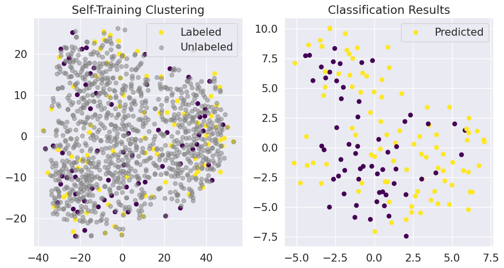

```python
# Self-training technique

train_labels = np.array(train_df['label'])
unlabeled_texts = unlabeled_df['text'].values

param_grid = {
    'n_estimators': [100, 200, 300],
    'max_features': ['auto', 'sqrt', 'log2'],
    'max_depth': [20],
    'min_samples_split': [2, 5],
    'min_samples_leaf': [1, 2],
    'bootstrap': [True]
}

classifier = RandomForestClassifier(random_state=42)
grid_search = GridSearchCV(estimator=classifier, param_grid=param_grid,
                           cv=3, n_jobs=-1, verbose=2)

grid_search.fit(train_reduced, train_labels)
classifier = grid_search.best_estimator_


max_iterations = 10
confidence_threshold = 0.9  # Threshold for considering a prediction confident
iteration = 0

while iteration < max_iterations:
    iteration += 1

    unlabeled_predictions = classifier.predict_proba(unlabeled_reduced)
    unlabeled_labels = classifier.predict(unlabeled_reduced)

    max_probs = np.max(unlabeled_predictions, axis=1)
    confident_indices = np.where(max_probs >= confidence_threshold)[0]

    if len(confident_indices) == 0:
        break

    confident_embeddings = unlabeled_reduced[confident_indices]
    confident_labels = unlabeled_labels[confident_indices]
    confident_texts = unlabeled_texts[confident_indices]

    train_reduced = np.vstack((train_reduced, confident_embeddings))
    train_labels = np.concatenate((train_labels, confident_labels))

    unlabeled_reduced = np.delete(unlabeled_reduced, confident_indices, axis=0)
    unlabeled_texts = np.delete(unlabeled_texts, confident_indices, axis=0)

    classifier.fit(train_reduced, train_labels)

    print(f"Iteration {iteration}: Added {len(confident_indices)} confident samples.")


test_predictions = classifier.predict(test_reduced)
print(classification_report(test_df['label'], test_predictions))

tsne = TSNE(n_components=2, random_state=42)
all_embeddings_pca = np.vstack((train_reduced, unlabeled_reduced))
all_embeddings_tsne = tsne.fit_transform(all_embeddings_pca)

labeled_embeddings_tsne = all_embeddings_tsne[:len(train_reduced)]
unlabeled_embeddings_tsne = all_embeddings_tsne[len(train_reduced):]

plt.figure(figsize=(12, 6))
plt.subplot(1, 2, 1)
plt.scatter(labeled_embeddings_tsne[:, 0], labeled_embeddings_tsne[:, 1], c=train_labels, cmap='viridis', label='Labeled')
plt.scatter(unlabeled_embeddings_tsne[:, 0], unlabeled_embeddings_tsne[:, 1], c='grey', alpha=0.5, label='Unlabeled')
plt.title('Self-Training Clustering')
plt.legend()

test_embeddings_tsne = tsne.fit_transform(test_reduced)
plt.subplot(1, 2, 2)
plt.scatter(test_embeddings_tsne[:, 0], test_embeddings_tsne[:, 1], c=test_predictions, cmap='viridis', label='Predicted')
plt.title('Classification Results')
plt.legend()

plt.show()
```

### KNN

```python
import numpy as np
import matplotlib.pyplot as plt
import seaborn as sns
from sklearn.decomposition import PCA
from sklearn.cluster import KMeans
from sklearn.neighbors import KNeighborsClassifier
from sklearn.metrics import accuracy_score, confusion_matrix
from sklearn.model_selection import GridSearchCV

# Prepare the data
X_train = np.array(train_df['embedding'].tolist())
y_train = train_df['label'].values
X_test = np.array(test_df['embedding'].tolist())
y_test = test_df['label'].values
X_unlabeled = np.array(unlabeled_df['embedding'].tolist())

# Apply PCA to reduce dimensionality to 150 components
pca = PCA(n_components=150)
X_train_pca = pca.fit_transform(X_train)
X_test_pca = pca.transform(X_test)
X_unlabeled_pca = pca.transform(X_unlabeled)

# Cluster the training data
kmeans = KMeans(n_clusters=2, random_state=0)
kmeans.fit(X_train_pca)


unlabeled_clusters = kmeans.predict(X_unlabeled_pca)


cluster_labels = {i: [] for i in range(2)}
for label, cluster in zip(y_train, kmeans.labels_):
    cluster_labels[cluster].append(label)

majority_labels = {cluster: max(set(labels), key=labels.count) for cluster, labels in cluster_labels.items()}


y_unlabeled_propagated = [majority_labels[cluster] for cluster in unlabeled_clusters]

# Combine labeled and unlabeled data
X_combined = np.vstack((X_train_pca, X_unlabeled_pca))
y_combined = np.concatenate((y_train, y_unlabeled_propagated))

# Define the parameter grid for the grid search
param_grid = {
    'n_neighbors': [3, 5, 7, 9 , 12 ,20],
    'weights': ['uniform', 'distance'],
    'algorithm': ['ball_tree', 'kd_tree', 'brute']
}

# Initialize GridSearchCV
knn = KNeighborsClassifier()
grid_search = GridSearchCV(estimator=knn, param_grid=param_grid, cv=3, n_jobs=-1, verbose=2)

# Train KNN on combined data with grid search
grid_search.fit(X_combined, y_combined)

# Get the best estimator
best_knn = grid_search.best_estimator_

# Predict on the test data
y_pred = best_knn.predict(X_test_pca)

# Confusion matrix and scoring
cm = make_confusion_matrix(y_test, y_pred)
scoring(cm)
```

```
Fitting 3 folds for each of 36 candidates, totalling 108 fits
```

```
WARNING:matplotlib.text:posx and posy should be finite values
WARNING:matplotlib.text:posx and posy should be finite values
WARNING:matplotlib.text:posx and posy should be finite values
WARNING:matplotlib.text:posx and posy should be finite values
```

```
Precision: 0.00
Recall: nan
F1 Score: nan
Accurcy: 0.48
micro average: 0.72
weighted_average: nan
macro average: nan
accuract: 0.48
```

### XGBoost

```python
import numpy as np
import matplotlib.pyplot as plt
import seaborn as sns
from sklearn.decomposition import PCA
from sklearn.cluster import KMeans
from sklearn.metrics import accuracy_score, confusion_matrix
from sklearn.model_selection import GridSearchCV
import xgboost as xgb

# Prepare the data
X_train = np.array(train_df['embedding'].tolist())
y_train = train_df['label'].values
X_test = np.array(test_df['embedding'].tolist())
y_test = test_df['label'].values
X_unlabeled = np.array(unlabeled_df['embedding'].tolist())

# Apply PCA to reduce dimensionality to 150 components
pca = PCA(n_components=150)
X_train_pca = pca.fit_transform(X_train)
X_test_pca = pca.transform(X_test)
X_unlabeled_pca = pca.transform(X_unlabeled)

# Cluster the training data
kmeans = KMeans(n_clusters=2, random_state=0)
kmeans.fit(X_train_pca)

# Predict clusters for the unlabeled data
unlabeled_clusters = kmeans.predict(X_unlabeled_pca)

# Determine majority label for each cluster
cluster_labels = {i: [] for i in range(2)}
for label, cluster in zip(y_train, kmeans.labels_):
    cluster_labels[cluster].append(label)

majority_labels = {cluster: max(set(labels), key=labels.count) for cluster, labels in cluster_labels.items()}

# Propagate majority labels to unlabeled data
y_unlabeled_propagated = [majority_labels[cluster] for cluster in unlabeled_clusters]

# Combine labeled and unlabeled data
X_combined = np.vstack((X_train_pca, X_unlabeled_pca))
y_combined = np.concatenate((y_train, y_unlabeled_propagated))

# Define the parameter grid for the grid search
param_grid = {
    'n_estimators': [ 100, 200],
    'learning_rate': [0.01, 0.1, 0.5, 1, 1.5],
    'max_depth': [7,  20 , 50]
}

# Initialize GridSearchCV
xgb_model = xgb.XGBClassifier(use_label_encoder=False, eval_metric='logloss')
grid_search = GridSearchCV(estimator=xgb_model, param_grid=param_grid, cv=3, n_jobs=-1, verbose=2)

# Train XGBoost on combined data with grid search
grid_search.fit(X_combined, y_combined)

# Get the best estimator
best_xgb = grid_search.best_estimator_

# Predict on the test data
y_pred = best_xgb.predict(X_test_pca)

cm = make_confusion_matrix(y_test, y_pred)
scoring(cm)
```

```
Fitting 3 folds for each of 30 candidates, totalling 90 fits
```

```
WARNING:matplotlib.text:posx and posy should be finite values
WARNING:matplotlib.text:posx and posy should be finite values
WARNING:matplotlib.text:posx and posy should be finite values
WARNING:matplotlib.text:posx and posy should be finite values
```

```
Precision: 0.00
Recall: nan
F1 Score: nan
Accurcy: 0.48
micro average: 0.72
weighted_average: nan
macro average: nan
accuract: 0.48
```

### In Summary

- **Random Forest**: Ensemble of decision trees, robust to overfitting, suitable for diverse tasks.
- **KMeans**: Clustering, unsupervised learning, useful for grouping similar items.
- **KNN**: Classification/regression based on nearest neighbors, simple and intuitive.
- **Logistic Regression**: Binary classification, probabilistic interpretation, linear relationships.
- **SVM**: Classification with optimal hyperplane, effective in high-dimensional spaces.
- **Decision Tree**: Classification/regression with interpretable rules, captures non-linear relationships.